# **Introduction to Data Science Long Assignment 2024/2025**

Lastly, we will tune the weight given to each group to decrease the negative influence of the imbalance of our dataset. Bayesian classifiers, such as Naive Bayes, do not have a class weight parameter. Bayesian classifiers calculate the probability of each class given the features and select the class with the highest probability. They do not directly weigh classes during the training process. Nonetheless, to handle class imbalance in a Bayesian classifier, we can adjust the prior probability of a class with the priors parameter. These priors can give more weight to the minority class by increasing its prior probability. If priors are not specified in a Naive Bayes classifier, the default behavior is for the classifier to estimate the class priors based on the frequency of each class in the training data, which leads to a high imbalance in our case.

```python
# Define the range of prior probabilities for class 0
class_0_priors = [0.1, 0.3, 0.5, 0.7, 0.9]
scores = []

# Iterate over different priors for class 0
for prior in class_0_priors:
    # Set priors for class 0 and class 1
    priors = [prior, 1 - prior]

    # Initialize and train the Naive Bayes model with specified priors
    nb_classifier = GaussianNB(var_smoothing = 1e-7, priors=priors)
    nb_preds_train = cross_val_predict(nb_classifier, X_train, y_train, cv=4)

    # Calculate F1 and Recall scores for class 0
    f1_group0 = f1_score(y_train, nb_preds_train, pos_label=0)
    recall_group0 = recall_score(y_train, nb_preds_train, pos_label=0)
    scores.append((prior, f1_group0, recall_group0))

    print(f"Prior for class 0: {prior}, F1 Score for class 0: {f1_group0}, Recall for class 0: {recall_group0}")
```

```
Prior for class 0: 0.1, F1 Score for class 0: 0.24472573839662448, Recall for class 0: 0.29565020389669233
Prior for class 0: 0.3, F1 Score for class 0: 0.26173811606882474, Recall for class 0: 0.40666062528318986
Prior for class 0: 0.5, F1 Score for class 0: 0.26996707718570906, Recall for class 0: 0.5015858631626643
Prior for class 0: 0.7, F1 Score for class 0: 0.27641610806938544, Recall for class 0: 0.6119166289080199
Prior for class 0: 0.9, F1 Score for class 0: 0.2659720318069646, Recall for class 0: 0.7691436338921613
```

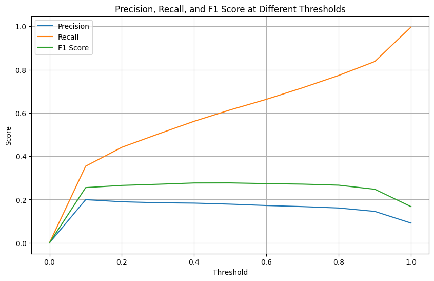

```python
# Final Model to test thresholds on
clf = GaussianNB(var_smoothing = 1e-7, priors=[0.7,0.3])
clf_preds_train = cross_val_predict(clf, X_train, y_train, cv=5)

# Get predicted probabilities for the positive class (1)
y_probs = cross_val_predict(clf, X_train, y_train, cv=5, method='predict_proba')[:, 1]

# Define thresholds to test
thresholds = np.arange(0.0, 1.1, 0.1)
metrics = {'threshold': [], 'precision': [], 'recall': [], 'f1': []}

for threshold in thresholds:
    precision, recall, f1 = evaluate_threshold(threshold, y_train, y_probs)
    metrics['threshold'].append(threshold)
    metrics['precision'].append(precision)
    metrics['recall'].append(recall)
    metrics['f1'].append(f1)

# Plot the metrics
plt.figure(figsize=(10, 6))
plt.plot(metrics['threshold'], metrics['precision'], label='Precision')
plt.plot(metrics['threshold'], metrics['recall'], label='Recall')
plt.plot(metrics['threshold'], metrics['f1'], label='F1 Score')
plt.xlabel('Threshold')
plt.ylabel('Score')
plt.title('Precision, Recall, and F1 Score at Different Thresholds')
plt.legend()
plt.grid()
plt.show()
```

```python
# Find the maximum F1 score and the corresponding threshold
max_f1_score = max(metrics['f1'])
max_f1_index = metrics['f1'].index(max_f1_score)
corresponding_threshold = metrics['threshold'][max_f1_index]

# Display the results
print("Maximum F1 Score:", max_f1_score)
print("Corresponding Threshold:", corresponding_threshold)
```

```
Maximum F1 Score: 0.27685866013071897
Corresponding Threshold: 0.5
```

We can see that we reach the highest F1 score with a threshold of 0.5. Therefore, we do not have to specify a special threshold for our model.

```
Performance on Training Dataset :

               precision    recall  f1-score   support

       False       0.18      0.61      0.28      4414
        True       0.95      0.72      0.82     44861

    accuracy                           0.71     49275
   macro avg       0.56      0.67      0.55     49275
weighted avg       0.88      0.71      0.77     49275

Performance on Validation Dataset :

               precision    recall  f1-score   support

       False       0.19      0.61      0.29      1983
        True       0.95      0.72      0.82     19136

    accuracy                           0.71     21119
   macro avg       0.57      0.67      0.55     21119
weighted avg       0.88      0.71      0.77     21119
```

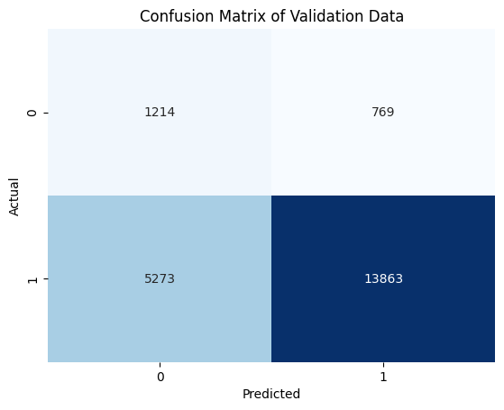

```python
# Print the classification report
clf.fit(X_train, y_train)
clf_preds_train = cross_val_predict(clf, X_train, y_train, cv=5)
clf_preds_valid = clf.predict(X_valid)
print("Performance on Training Dataset : \n\n", classification_report(y_train, clf_preds_train))
print("Performance on Validation Dataset : \n\n", classification_report(y_valid, clf_preds_valid))

# Plot the Confusion matrix
cm = confusion_matrix(y_valid, clf_preds_valid)
sns.heatmap(cm, annot=True, fmt='d', cmap='Blues', cbar=False)

plt.xlabel('Predicted')
plt.ylabel('Actual')
plt.title('Confusion Matrix of Validation Data')
plt.show()
```

Looking at the classification reports and confusion matrix, specifying the prior probabilities did not increase the F1 score, but the recall (at the cost of precision). Therefore, the prior probabilities help us to focus the model more on our project goals. The F1 score for the uninsured class of the final model is 0.29. Therefore, the comparisons made with the knn model and logistic regression made earlier still hold true. The Bayesian classifiers performs significantly better than the knn model and slightly worse than the Logistic Regression with the main difference being that the Bayesian Classifier achieves a high recall and a less balanced tradeoff between recall and precision.

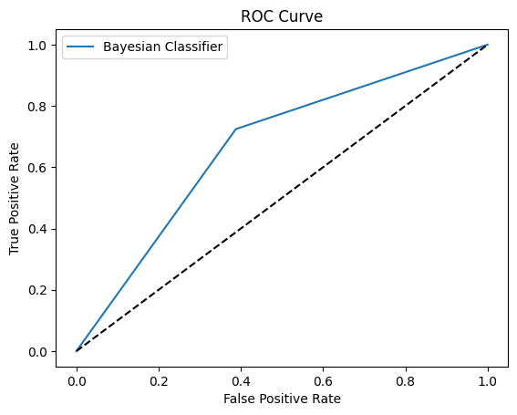

```
AUC Score: 0.6683249009768651
```

```python
# ROC plot for the Bayesian Classifier
tpr, fpr, thresholds = roc_curve(y_valid, clf_preds_valid, pos_label=0)
plt.plot(fpr, tpr, label='Bayesian Classifier')
plt.plot([0, 1], [0, 1], 'k--')
plt.xlabel('False Positive Rate')
plt.ylabel('True Positive Rate')
plt.title('ROC Curve')
plt.legend()
plt.show()

print("AUC Score:", roc_auc_score(y_valid, clf_preds_valid))
```

The ROC curve shows that, in contrast to the knn model, the Bayesian classifier performs significantly better than random guessing. This is reflected in the AUC score of 0.67, which almost equal to the AUC score of the logistic regression. This means that both models have comparable abilities when it comes to distinguishing between the uninsured and insured cases. Both models have some ability to distinguish the uninsured, but it is limited.

```python
# Generate the classification report as a dictionary
report = classification_report(y_valid, clf_preds_valid, output_dict=True)

# Extract metrics from the report
accuracy = report["accuracy"]
recall_false = report["False"]["recall"]
f1_score_false = report["False"]["f1-score"]
f1_score_weighted = report["weighted avg"]["f1-score"]
f1_score_macro = report["macro avg"]["f1-score"]


# Save them in csv file
save_metrics_to_csv(
    model_name="bayesian classifier with imbalanced data",
    accuracy=accuracy,
    recall_false=recall_false,
    f1_score_false=f1_score_false,
    f1_score_weighted=f1_score_weighted,
    f1_score_macro=f1_score_macro,
    file_path='/content/drive/My Drive/IDS_model_metrics.csv'
)
```

## Decision Tree

We will now implement a decision tree model. Decision trees are a popular and intuitive machine learning method used for both classification and regression tasks. They are valued for their interpretability, as they clearly show the decision-making process, making it easy to understand how individual predictions are reached. However, they can be prone to overfitting, particularly with complex data, so techniques like pruning or ensemble methods are often applied to improve their generalizability. First, we will just use the default parameters. Then, we will implement a Grid Search to find the best parameters to prevent the issue of overfitting.

```python
tree_clf = DecisionTreeClassifier()
tree_preds_train = cross_val_predict(tree_clf, X_train, y_train, cv=5)

# Print the classification report
print(classification_report(y_train, tree_preds_train))
```

```
              precision    recall  f1-score   support

       False       0.20      0.23      0.21      4414
        True       0.92      0.91      0.91     44861

    accuracy                           0.85     49275
   macro avg       0.56      0.57      0.56     49275
weighted avg       0.86      0.85      0.85     49275
```

The non-finetuned model performs worse than the non-tuned Bayesian Classifier but significantly better than the non-tuned Logistic Regression. This is, however, due to the exceptional bad performance of the Logistic Regression before tuning. As with all models, the F1 score of the uninsured cases is the greatest problem. The precision and recall are equally bad for the uninsured in the non-tuned Decision Tree.

One key parameter of the decision tree is max_depth, which controls the maximum number of splits the tree can make from the root to any leaf. Limiting depth helps prevent overfitting by stopping the tree from learning overly complex patterns that may not generalize well. Min_samples_split sets the minimum number of samples required to split a node, reducing overfitting by ensuring that nodes are split only if there is sufficient data. Similarly, min_samples_leaf defines the minimum number of samples allowed in a leaf node, preventing the model from creating overly specific predictions based on tiny data subsets. We will now search the best values for these parameters to optimize the performance.

```python
# Define a custom scorer for the recall of class 0
negative_class_recall_scorer = make_scorer(recall_score, pos_label=0)

# Define parameters to be tested
param_grid = {
    'max_depth': [5, 10, 20, 30, 40],
    'min_samples_split': [2, 5, 10, 15],
    'min_samples_leaf': [1, 2, 4, 8]
}

# Perform the grid search with the custom scorer
grid_search = GridSearchCV(tree_clf, param_grid, cv=5, scoring=negative_class_recall_scorer)
grid_search.fit(X_train, y_train)

# Retrieve the best parameters and model
best_params = grid_search.best_params_
tree_clf = grid_search.best_estimator_

print("Best Parameters:", best_params)
```

```
Best Parameters: {'max_depth': 40, 'min_samples_leaf': 2, 'min_samples_split': 5}
```

```
Performance on Training Dataset :

               precision    recall  f1-score   support

       False       0.19      0.25      0.21      4414
        True       0.92      0.89      0.91     44861

    accuracy                           0.84     49275
   macro avg       0.56      0.57      0.56     49275
weighted avg       0.86      0.84      0.85     49275

Performance on Validation Dataset :

               precision    recall  f1-score   support

       False       0.20      0.25      0.22      1983
        True       0.92      0.89      0.91     19136

    accuracy                           0.83     21119
   macro avg       0.56      0.57      0.56     21119
weighted avg       0.85      0.83      0.84     21119
```

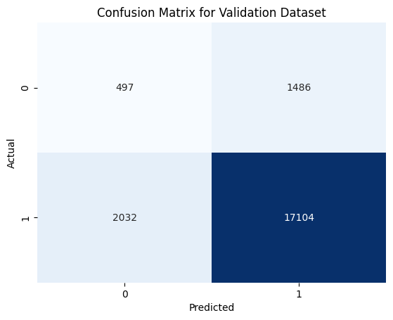

```python
tree_preds_train = cross_val_predict(tree_clf, X_train, y_train, cv=5)
tree_preds_valid = tree_clf.predict(X_valid)

# Print the classification report
print("Performance on Training Dataset : \n\n", classification_report(y_train, tree_preds_train))
print("Performance on Validation Dataset : \n\n", classification_report(y_valid, tree_preds_valid))

# Print Confusion Matrix                                                                        # Plot the Confusion matrix
cm = confusion_matrix(y_valid, tree_preds_valid)
sns.heatmap(cm, annot=True, fmt='d', cmap='Blues', cbar=False)

plt.xlabel('Predicted')
plt.ylabel('Actual')
plt.title('Confusion Matrix for Validation Dataset')
plt.show()
```

Comparing the non-tuned and tuned models, there is a slight improvement in the recall of the uninsured class. The non-tuned model has a recall of 0.23 for the uninsured, while the tuned model increases this slightly to 0.25 on both the training and validation sets. While the overall accuracy and other metrics such as F1 remain largely unchanged, the tuning has made a small adjustment to better identify the uninsured cases, which is especially important given the dataset’s imbalance. We can, however, conclude that the finetuning of the parameters was not as powerful as with the other models.

We will now use balanced class weights to see if that enables us to improve the model performance.

```
Performance on Training Dataset :

               precision    recall  f1-score   support

       False       0.19      0.36      0.25      4414
        True       0.93      0.84      0.89     44861

    accuracy                           0.80     49275
   macro avg       0.56      0.60      0.57     49275
weighted avg       0.86      0.80      0.83     49275

Performance on Validation Dataset :

               precision    recall  f1-score   support

       False       0.19      0.36      0.25      1983
        True       0.93      0.84      0.88     19136

    accuracy                           0.79     21119
   macro avg       0.56      0.60      0.56     21119
weighted avg       0.86      0.79      0.82     21119
```

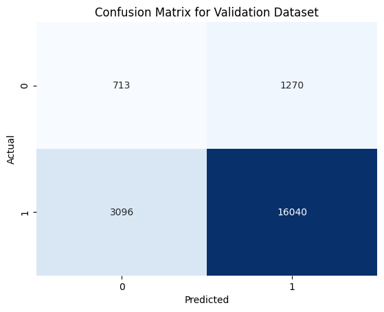

```python
tree_clf = DecisionTreeClassifier(max_depth = 30, class_weight="balanced", min_samples_leaf= 4, min_samples_split= 5)
tree_clf.fit(X_train, y_train)
tree_preds_train = cross_val_predict(tree_clf, X_train, y_train, cv=5)
tree_preds_valid = tree_clf.predict(X_valid)

# Print the classification report
print("Performance on Training Dataset : \n\n", classification_report(y_train, tree_preds_train))
print("Performance on Validation Dataset : \n\n", classification_report(y_valid, tree_preds_valid))

# Plot the Confusion matrix
cm = confusion_matrix(y_valid, tree_preds_valid)
sns.heatmap(cm, annot=True, fmt='d', cmap='Blues', cbar=False)

plt.xlabel('Predicted')
plt.ylabel('Actual')
plt.title('Confusion Matrix for Validation Dataset')
plt.show()
```

With the introduction of balanced class weights, the recall for the uninsured class has improved compared to the previous models. In the non-tuned model, recall for the uninsured was 0.23, and after tuning, it increased to 0.25. With balanced class weights, recall further improves to 0.36 on the training as well as validation dataset. While the precision for the uninsured class remains similar, the increase in recall indicates that balancing the class weights has helped the model identify more uninsured cases. This also leads to a slightly higher F1 score. Overall, the model’s accuracy and weighted average metrics remain consistent, but the higher recall reflects a more effective focus on our prioritized class. When compared to the other models, the Decision Tree is, however, outperformed by the Logistic Regression as well as the Bayesian Classifier. Both yield a higher recall and F1 score.

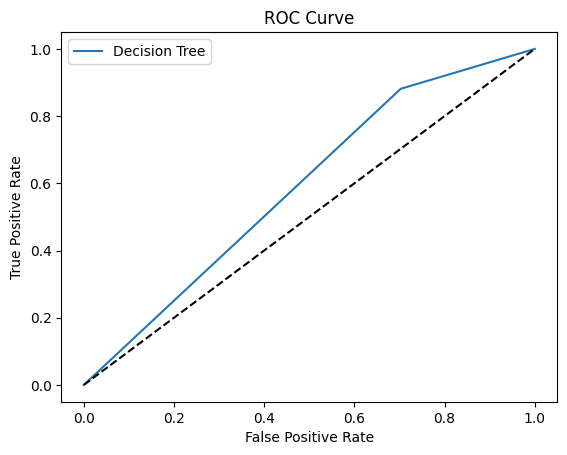

```
AUC Score: 0.5892261928102922
```

```python
# ROC plot for the Decision Tree
tpr, fpr, thresholds = roc_curve(y_valid, tree_preds_valid, pos_label=0)
plt.plot(fpr, tpr, label='Decision Tree')
plt.plot([0, 1], [0, 1], 'k--')
plt.xlabel('False Positive Rate')
plt.ylabel('True Positive Rate')
plt.title('ROC Curve')
plt.legend()
plt.show()

print("AUC Score:", roc_auc_score(y_valid, tree_preds_valid))
```

The ROC curve and AUC score shows that the the Decision Tree performs slightly better than random guessing. Therefore, as already shown in the classification report, its performance is between the knn model and the Logistic Regression/Bayesian Classifier. In conclusion, the performance is mediocre.

```python
# Generate the classification report as a dictionary
report = classification_report(y_valid, tree_preds_valid, output_dict=True)

# Extract metrics from the report
accuracy = report["accuracy"]
recall_false = report["False"]["recall"]
f1_score_false = report["False"]["f1-score"]
f1_score_weighted = report["weighted avg"]["f1-score"]
f1_score_macro = report["macro avg"]["f1-score"]


# Save them in csv file
save_metrics_to_csv(
    model_name="decision tree with imbalanced data",
    accuracy=accuracy,
    recall_false=recall_false,
    f1_score_false=f1_score_false,
    f1_score_weighted=f1_score_weighted,
    f1_score_macro=f1_score_macro,
    file_path='/content/drive/My Drive/IDS_model_metrics.csv'
)
```

## Random Forest

As a next model, we will build a random forest. Random Forest is an ensemble learning method used for classification and regression tasks, which combines multiple decision trees to improve predictive accuracy and control overfitting. It works by constructing a collection of decision trees during training, each trained on a random subset of the data with bootstrapping (sampling with replacement). The final prediction is made by aggregating the predictions from all individual trees, either through majority voting (for classification) or averaging (for regression). Random Forest is highly versatile, robust to overfitting, and performs well on both small and large datasets with minimal tuning.

```python
# Set up Default Model
rf_clf = RandomForestClassifier()
rf_clf.fit(X_train, y_train)
rf_preds_valid = rf_clf.predict(X_valid)

# Print the classification report
print(classification_report(y_valid, rf_preds_valid))
```

```
              precision    recall  f1-score   support

       False       0.33      0.03      0.06      1983
        True       0.91      0.99      0.95     19136

    accuracy                           0.90     21119
   macro avg       0.62      0.51      0.51     21119
weighted avg       0.85      0.90      0.87     21119
```

The untuned Random Forest shows an exceptionally bad performance. It only achieves a F1 score of 0.06 for the uninsured class. This is primarily driven by the very low recall of 0.03. We will attempt to increase the performance by finetuning the parameters.

```python
n_trees = [5, 10, 20, 50, 100, 200]
train_recall = {}

for n in n_trees:
    # Set up Random Forest and fit the model
    rf = RandomForestClassifier(n_estimators=n, max_depth = 30, min_samples_leaf= 2, min_samples_split= 5)
    rf_preds_train = cross_val_predict(rf, X_train, y_train, cv=4)

    # Compute recall
    train_recall[n] = recall_score(y_train, rf_preds_train, pos_label=0)

print(train_recall)
```

```
{5: 0.08450385138196648, 10: 0.04802899864068872, 20: 0.03579519710013593, 50: 0.02650657000453104, 100: 0.025373810602628003, 200: 0.021295876755777075}
```

```
Performance on Training Dataset :

               precision    recall  f1-score   support

       False       0.28      0.08      0.13      4414
        True       0.92      0.98      0.95     44861

    accuracy                           0.90     49275
   macro avg       0.60      0.53      0.54     49275
weighted avg       0.86      0.90      0.87     49275

Performance on Validation Dataset :

               precision    recall  f1-score   support

       False       0.28      0.08      0.12      1983
        True       0.91      0.98      0.94     19136

    accuracy                           0.89     21119
   macro avg       0.60      0.53      0.53     21119
weighted avg       0.85      0.89      0.87     21119
```

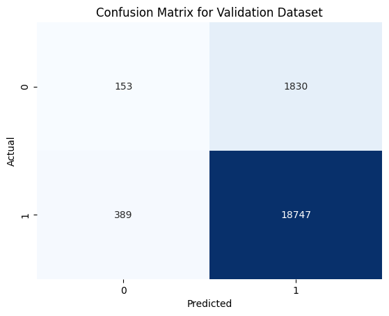

```python
# Set up final model
rf = RandomForestClassifier(n_estimators=5, max_depth = 30, min_samples_leaf= 2, min_samples_split= 5)
rf.fit(X_train,y_train)
rf_preds_train = cross_val_predict(rf, X_train, y_train, cv=5)
rf_preds_valid = rf.predict(X_valid)

# Print the classification report
print("Performance on Training Dataset : \n\n", classification_report(y_train, rf_preds_train))
print("Performance on Validation Dataset : \n\n", classification_report(y_valid, rf_preds_valid))

# Print Confusion Matrix
cm = confusion_matrix(y_valid, rf_preds_valid)
sns.heatmap(cm, annot=True, fmt='d', cmap='Blues', cbar=False)

plt.xlabel('Predicted')
plt.ylabel('Actual')
plt.title('Confusion Matrix for Validation Dataset')
plt.show()
```

One possible solution to improve the performance could be to adjust the class weights.

```
Performance on Training Dataset :

               precision    recall  f1-score   support

       False       0.24      0.18      0.21      4414
        True       0.92      0.95      0.93     44861

    accuracy                           0.88     49275
   macro avg       0.58      0.56      0.57     49275
weighted avg       0.86      0.88      0.87     49275

Performance on Validation Dataset :

               precision    recall  f1-score   support

       False       0.25      0.20      0.22      1983
        True       0.92      0.94      0.93     19136

    accuracy                           0.87     21119
   macro avg       0.59      0.57      0.58     21119
weighted avg       0.86      0.87      0.86     21119
```

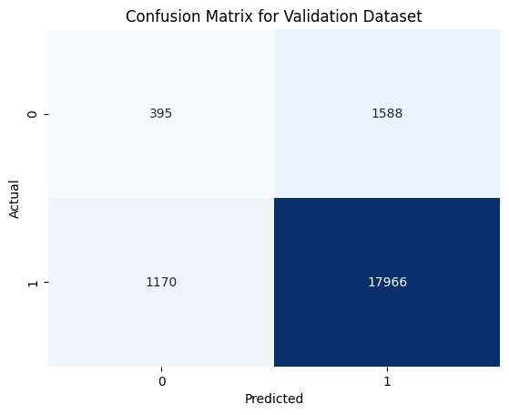

```python
# Set up final model with balanced class weights
rf = RandomForestClassifier(n_estimators=5, max_depth = 30, min_samples_leaf= 2, min_samples_split= 5, class_weight="balanced")
rf.fit(X_train,y_train)
rf_preds_train = cross_val_predict(rf, X_train, y_train, cv=5)
rf_preds_valid = rf.predict(X_valid)

# Print the classification report
print("Performance on Training Dataset : \n\n", classification_report(y_train, rf_preds_train))
print("Performance on Validation Dataset : \n\n", classification_report(y_valid, rf_preds_valid))

# Print Confusion Matrix
cm = confusion_matrix(y_valid, rf_preds_valid)
sns.heatmap(cm, annot=True, fmt='d', cmap='Blues', cbar=False)

plt.xlabel('Predicted')
plt.ylabel('Actual')
plt.title('Confusion Matrix for Validation Dataset')
plt.show()
```

Using balanced class weights leads to a significant performance improvement. This adjustment approximately doubled the recall and F1 score. Nonetheless, the Random Forest still performs worse than the single Decision Tree. Therefore, it also performs worse than the Logistic Regression and Bayesian Classifier - it only outperforms the knn.

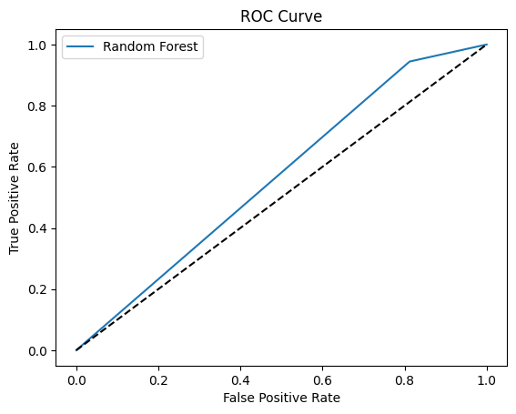

```
AUC Score: 0.5660224022713128
```

```python
# ROC plot for the Random Forest
tpr, fpr, thresholds = roc_curve(y_valid, rf_preds_valid, pos_label=0)
plt.plot(fpr, tpr, label='Random Forest')
plt.plot([0, 1], [0, 1], 'k--')
plt.xlabel('False Positive Rate')
plt.ylabel('True Positive Rate')
plt.title('ROC Curve')
plt.legend()
plt.show()

print("AUC Score:", roc_auc_score(y_valid, rf_preds_valid))
```

The ROC curve and AUC score show that the Random Forest only performs slightly better than random guessing at identifying uninsured cases. This speaks strongly against the model and is in line with the findings of the classification report.

```python
# Generate the classification report as a dictionary
report = classification_report(y_valid, rf_preds_valid, output_dict=True)

# Extract metrics from the report
accuracy = report["accuracy"]
recall_false = report["False"]["recall"]
f1_score_false = report["False"]["f1-score"]
f1_score_weighted = report["weighted avg"]["f1-score"]
f1_score_macro = report["macro avg"]["f1-score"]


# Save them in csv file
save_metrics_to_csv(
    model_name="random forest with imbalanced data",
    accuracy=accuracy,
    recall_false=recall_false,
    f1_score_false=f1_score_false,
    f1_score_weighted=f1_score_weighted,
    f1_score_macro=f1_score_macro,
    file_path='/content/drive/My Drive/IDS_model_metrics.csv'
)
```

## Support Vector Machine (SVM)

Now we will implement a SVM Model. SVM works by finding the optimal hyperplane that best separates data points of different classes in a high-dimensional space, maximizing the margin between the closest points (support vectors) of each class.

```python
# Set up default model
svm = SVC()
svm_preds_train = cross_val_predict(svm, X_train, y_train, cv=5)
print(classification_report(y_train, svm_preds_train))
```

```
              precision    recall  f1-score   support

       False       0.00      0.00      0.00      4414
        True       0.91      1.00      0.95     44861

    accuracy                           0.91     49275
   macro avg       0.46      0.50      0.48     49275
weighted avg       0.83      0.91      0.87     49275
```

The default model performs extremely poorly. The recall, precision, and F1 score for the uninsured class is 0, meaning that the model does not identify any instance as uninsured. Therefore, the model would not lead to any benefits for the company. We will now proceed to finetuning the parameters to see if we can improve the performance. Considering that SVM is a computationally very exhaustive algorithm, we decided to only use half of the training data to search for the optimal parameters. In this way, we can implement a Grid Search to find the very best combination of parameter values. Before opting for this approach, we already attempted other methods for finding the best parameters, which require less computing power than Grid Search (e.g. Randomized Search and Bayesian methods). Although these methods require less computing power, using the complete training data with them still resulted in too extensive runtimes. Therefore, we decided to do the exhaustive Grid Search and use only a fraction of the training data.

```python
# Slice the first half of the training data to reduce computational complexity
half_X_train = X_train[:len(X_train)//2]
half_y_train = y_train[:len(y_train)//2]

# Define a custom scorer for the recall of class 0
negative_class_recall_scorer = make_scorer(recall_score, pos_label=0)

# Define parameter grid
param_grid = {'C': [0.1, 1, 10, 100, 1000, 1500, 2000],
              'gamma': [1, 0.1, 0.01, 0.001, 0.0001],
              'kernel': ['rbf']}

# Initialize GridSearchCV with the custom scorer and parameter grid
grid = GridSearchCV(SVC(), param_grid, cv=5, scoring=negative_class_recall_scorer)

# Fit the model for grid search using only the first half of the training data
grid.fit(half_X_train, half_y_train)

# Retrieve the best parameters and model
best_params = grid.best_params_
svm = grid.best_estimator_

print("Best Parameters:", best_params)
```

```
Best Parameters: {'C': 1000, 'gamma': 0.1, 'kernel': 'rbf'}
```

The parameter C, often called the regularization parameter, controls the trade-off between maximizing the margin and minimizing classification errors. A high C value, such as 1000 in this case, implies a stronger emphasis on correctly classifying all training data points, even if it results in a more complex decision boundary. This value suggests that the model prioritizes precision over margin maximization. Such a high value might be necessary due to the imbalanced nature of our dataset. A low C might lead to a "smoothing out" of the few uninsured classes so that all cases would be classified as insured. Gamma defines the influence of a single training example. A gamma of 0.1 indicates a moderate level of influence for each data point, balancing between a broad and narrow reach of each support vector in the decision boundary. A lower gamma means that the decision boundary is smoother, which can help in avoiding overfitting. The rbf (Radial Basis Function) kernel is a popular choice for non-linear SVMs, allowing the model to capture complex patterns in the data by projecting it into a higher-dimensional space. This kernel is particularly effective when data is not linearly separable.

```
Performance on Training Dataset :

               precision    recall  f1-score   support

       False       0.20      0.20      0.20      4414
        True       0.92      0.92      0.92     44861

    accuracy                           0.86     49275
   macro avg       0.56      0.56      0.56     49275
weighted avg       0.86      0.86      0.86     49275

Performance on Validation Dataset :

               precision    recall  f1-score   support

       False       0.22      0.21      0.22      1983
        True       0.92      0.92      0.92     19136

    accuracy                           0.86     21119
   macro avg       0.57      0.57      0.57     21119
weighted avg       0.85      0.86      0.85     21119
```

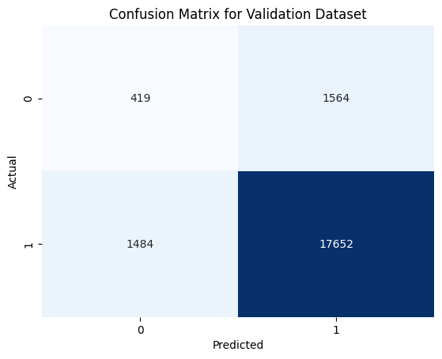

```python
# Set up finetuned model
svm = SVC(C=1000,gamma=0.1,kernel="rbf")
svm.fit(X_train, y_train)
svm_preds_train = cross_val_predict(svm, X_train, y_train, cv=5)
svm_preds_valid = svm.predict(X_valid)

# Print classification report
print("Performance on Training Dataset : \n\n", classification_report(y_train, svm_preds_train))
print("Performance on Validation Dataset : \n\n", classification_report(y_valid, svm_preds_valid))

# Plot the confusion matrix
cm = confusion_matrix(y_valid, svm_preds_valid)
sns.heatmap(cm, annot=True, fmt='d', cmap='Blues', cbar=False)

plt.xlabel('Predicted')
plt.ylabel('Actual')
plt.title('Confusion Matrix for Validation Dataset')
plt.show()
```

The performance on the training and validation dataset is approximately the same. While it has significantly improved when compared to the performance of the default model, it is still not satisfactory and worse than some of the other models. Both precision and recall for the uninsured class are approximately 0.2. Considering that this is likely caused by the imbalance of our dataset, we will finetune the class_weight parameter.

The class_weight="balanced" parameter in SVMs adjusts the weights of each class inversely proportional to their frequencies in the data, which helps to address class imbalance. When this parameter is set, the model automatically assigns higher weight to the minority class (the class with fewer samples) and lower weight to the majority class. This balancing encourages the model to treat misclassifications in both classes with more equality, improving recall and precision for the minority class.

```python
# Set up finetuned model with balanced class weights
svm = SVC(class_weight="balanced", C=1000, gamma = 0.1, kernel ="rbf", probability = True)
svm.fit(X_train, y_train)
svm_preds_train = cross_val_predict(svm, X_train, y_train, cv=3)

# Print classification report
print("Performance on Training Dataset : \n\n", classification_report(y_train, svm_preds_train))
```

```
Performance on Training Dataset :

               precision    recall  f1-score   support

       False       0.20      0.21      0.21      4414
        True       0.92      0.92      0.92     44861

    accuracy                           0.85     49275
   macro avg       0.56      0.56      0.56     49275
weighted avg       0.86      0.85      0.86     49275
```

Although the recall, and thereby also the F1 score, for the uninsured class increases slightly, the improvement is only minor. The last parameter we can finetune is the cutoff score for the decision function. The output of the SVM is the signed distance of a data point from this hyperplane and the decision function for an SVM produces a continuous score for each sample, which is the distance from the decision boundary (hyperplane). The sign of this score indicates which class the model predicts. A positive score suggests the sample belongs to one class (e.g., class 1). A negative score suggests the sample belongs to the other class (e.g., class 0). By default, SVM classifies a sample as belonging to class 1 if the decision function value is greater than or equal to 0, and to class 0 if the value is less than 0. This means the decision threshold is at 0 (the hyperplane). However, it is possible to adjust this threshold to control the decision boundary if needed, especially in imbalanced datasets or when we require probabilistic outputs (for example, when using the probability=True option in scikit-learn’s SVC, which applies Platt scaling to estimate probabilities). So, while the core decision boundary is at zero by default, we can interpret and adjust this threshold to better suit our needs.

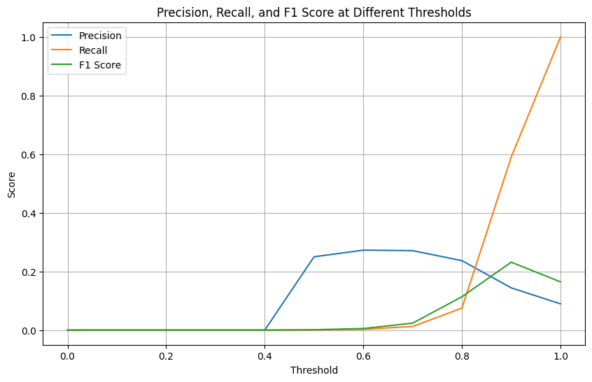

```python
# Get predicted probabilities for the positive class (1)
y_probs = cross_val_predict(svm, X_train, y_train, cv=3, method='predict_proba')[:, 1]

# Define thresholds to test
thresholds = np.arange(0.0, 1.1, 0.1)
metrics = {'threshold': [], 'precision': [], 'recall': [], 'f1': []}

for threshold in thresholds:
    precision, recall, f1 = evaluate_threshold(threshold, y_train, y_probs)
    metrics['threshold'].append(threshold)
    metrics['precision'].append(precision)
    metrics['recall'].append(recall)
    metrics['f1'].append(f1)

# Plot the metrics
plt.figure(figsize=(10, 6))
plt.plot(metrics['threshold'], metrics['precision'], label='Precision')
plt.plot(metrics['threshold'], metrics['recall'], label='Recall')
plt.plot(metrics['threshold'], metrics['f1'], label='F1 Score')
plt.xlabel('Threshold')
plt.ylabel('Score')
plt.title('Precision, Recall, and F1 Score at Different Thresholds')
plt.legend()
plt.grid()
plt.show()
```

Similar to the other models producing probability scores, the F1 score is maximized with a very high threshold of 0.9. Nonetheless, it does not seem to surpass 0.3. Therefore, SVM does not belong to one of the better performing models.

```
Classification Report for Validation Dataset with Threshold = 0.9:
              precision    recall  f1-score   support

       False       0.15      0.59      0.24      1983
        True       0.94      0.65      0.77     19136

    accuracy                           0.64     21119
   macro avg       0.54      0.62      0.50     21119
weighted avg       0.86      0.64      0.72     21119
```

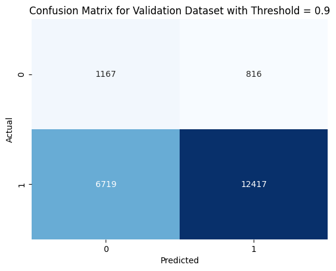

```python
svm = SVC(class_weight="balanced", C=1000, gamma = 0.1, kernel ="rbf", probability = True)
svm.fit(X_train, y_train)
svm_preds_valid = svm.predict_proba(X_valid)[:, 1]
svm_preds_valid_threshold = (svm_preds_valid >= 0.9).astype(int)

# Print the classification report
print("Classification Report for Validation Dataset with Threshold = 0.9:")
print(classification_report(y_valid, svm_preds_valid_threshold))

# Plot the Confusion Matrix
cm = confusion_matrix(y_valid, svm_preds_valid_threshold)
sns.heatmap(cm, annot=True, fmt='d', cmap='Blues', cbar=False)

plt.xlabel('Predicted')
plt.ylabel('Actual')
plt.title('Confusion Matrix for Validation Dataset with Threshold = 0.9')
plt.show()
```

The tuning of the cutoff score for the probability did not help to increase the F1 score, but we managed to get a higher recall at the cost of precision. Considering our business problem, which requires us to prioritze recall as explained earlier, this can be seen as a success. Nonetheless, the model does not outperform other models.

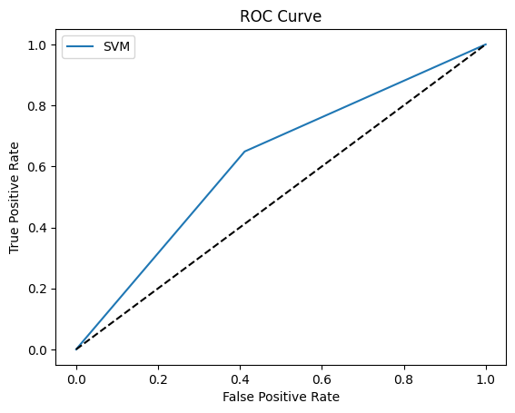

```
AUC Score: 0.6186919791260834
```

```python
# ROC plot for SVM
tpr, fpr, thresholds = roc_curve(y_valid, svm_preds_valid_threshold, pos_label=0)
plt.plot(fpr, tpr, label='SVM')
plt.plot([0, 1], [0, 1], 'k--')
plt.xlabel('False Positive Rate')
plt.ylabel('True Positive Rate')
plt.title('ROC Curve')
plt.legend()
plt.show()

print("AUC Score:", roc_auc_score(y_valid, svm_preds_valid_threshold))
```

The ROC curve visualizes the findings from the classification report. While the SVM outperforms random guessing, it is only a small difference (as indicated by the AUC score of 0.61).

```python
# Generate the classification report as a dictionary
report = classification_report(y_valid, svm_preds_valid_threshold, output_dict=True)

# Extract metrics from the report
accuracy = report["accuracy"]
recall_false = report["False"]["recall"]
f1_score_false = report["False"]["f1-score"]
f1_score_weighted = report["weighted avg"]["f1-score"]
f1_score_macro = report["macro avg"]["f1-score"]


# Save them in csv file
save_metrics_to_csv(
    model_name="svm with imbalanced data",
    accuracy=accuracy,
    recall_false=recall_false,
    f1_score_false=f1_score_false,
    f1_score_weighted=f1_score_weighted,
    f1_score_macro=f1_score_macro,
    file_path='/content/drive/My Drive/IDS_model_metrics.csv'
)
```

## XGBoost (Extreme Gradient Boosting)

Considering the unsatisfying performance our models, we will now implement a more powerful and recent model. XGBoost (Extreme Gradient Boosting) is a powerful and widely used machine learning algorithm based on the gradient boosting framework. It is designed for speed and performance, offering both high computational efficiency and model accuracy. XGBoost employs an ensemble of decision trees, sequentially built to minimize a specified loss function, while incorporating regularization techniques such as L1 and L2 penalties to reduce overfitting. Its scalability is enhanced by parallel processing, tree pruning, and efficient handling of missing values.

```python
# XGBoost needs a numpy format

# Convert to numpy array
X_train_numpy = X_train.to_numpy()
y_train_numpy = y_train.to_numpy()
X_valid_numpy = X_valid.to_numpy()

# Set up the default model
xgb_classifier = xgb.XGBClassifier(
    objective="binary:logistic",
    random_state = 42)

xgb_preds_train = cross_val_predict(xgb_classifier, X_train_numpy, y_train_numpy, cv=5)

print(classification_report(y_train, xgb_preds_train))
```

```
              precision    recall  f1-score   support

       False       0.39      0.07      0.12      4414
        True       0.92      0.99      0.95     44861

    accuracy                           0.91     49275
   macro avg       0.65      0.53      0.54     49275
weighted avg       0.87      0.91      0.88     49275
```

We will now proceed to parameter tuning to see if that improves the performance. Considering the large amount of possible parameters to tune, we decided to focus on the most powerful ones. The learning_rate determines the size of the step the model takes in updating weights during training, with smaller values allowing more precise convergence at the cost of longer training times. Max_depth sets the maximum depth of each decision tree, controlling model complexity and its ability to capture intricate patterns while avoiding overfitting. Gamma specifies the minimum loss reduction required for a node split, thus pruning less informative splits. Subsample controls the fraction of training data used for each boosting iteration, reducing overfitting when set to values below 1. Lambda and alpha represent L2 and L1 regularization terms, respectively, penalizing large weights to prevent overfitting and improve model generalization.

```python
# Define a custom scorer for the recall of class 0
negative_class_recall_scorer = make_scorer(recall_score, pos_label=0)

# Set up the XGBClassifier
xgb_classifier = xgb.XGBClassifier(
    objective="binary:logistic",
    random_state=42
)

# Define the parameter distributions for RandomizedSearch
param_distributions = {
    'learning_rate': [0.05, 0.2, 0.3, 0.4, 0.6, 0.8],
    'max_depth': list(range(3, 11, 2)),
    'gamma': [0, 0.5, 1],
    'subsample': [0.01, 0.1, 0.3, 0.5, 1.0],
    'lambda': [1e-5, 0.1, 1, 100],
    'alpha': [1e-5, 0.1, 1, 100]
}

# Set up RandomizedSearchCV with 3-fold cross-validation
random_search = RandomizedSearchCV(
    estimator=xgb_classifier,
    param_distributions=param_distributions,
    scoring=negative_class_recall_scorer,
    cv=3,  # 3-fold cross-validation
    verbose=1,  # Shows progress during the random search
    n_jobs=-1,  # Use all available cores for parallel processing
    n_iter=50,  # Number of parameter settings that are sampled
    random_state=42  # Ensures reproducibility of the search
)

# Fit the randomized search to the data
random_search.fit(X_train_numpy, y_train_numpy)

# Best hyperparameters found
print("Best hyperparameters:", random_search.best_params_)

# Best model from randomized search
xgb_best_model = random_search.best_estimator_
```

```
Fitting 3 folds for each of 50 candidates, totalling 150 fits
Best hyperparameters: {'subsample': 0.01, 'max_depth': 7, 'learning_rate': 0.3, 'lambda': 1e-05, 'gamma': 1, 'alpha': 1}
```

The identified best hyperparameters suggest a specific configuration for the XGBoost model that balances complexity and regularization. A subsample value of 1% indicates that only a small fraction of the training data is used in each boosting iteration, which helps reduce overfitting by introducing variability but may increase bias. The maximum tree depth of 7 allows the model to capture complex patterns and interactions in the data, though it increases the risk of overfitting if not counterbalanced by other measures. A high learning rate of 0.3 can be considered moderate and leads to an efficient tradeoff between enabling the model to make larger updates during training, prioritizing faster convergence while limiting the risk of overshooting optimal solutions. The low L2 regularization value suggests that the model does not heavily penalize large weights, likely because the data does not require strong constraints to avoid overfitting. In contrast, a moderate level of L1 regularization promotes sparsity by shrinking less important feature weights to zero. Finally, a moderate threshold for the minimum loss reduction required to make a split ensures that only meaningful splits are added to the trees. This configuration likely reflects the data's need for deep, expressive trees with controlled regularization and variability to optimize performance.

```
Performance on Training Dataset :

               precision    recall  f1-score   support

       False       0.18      0.24      0.21      4414
        True       0.92      0.89      0.91     44861

    accuracy                           0.83     49275
   macro avg       0.55      0.57      0.56     49275
weighted avg       0.86      0.83      0.84     49275

Performance on Validation Dataset :

               precision    recall  f1-score   support

       False       0.19      0.23      0.20      1983
        True       0.92      0.90      0.91     19136

    accuracy                           0.83     21119
   macro avg       0.55      0.56      0.56     21119
weighted avg       0.85      0.83      0.84     21119
```

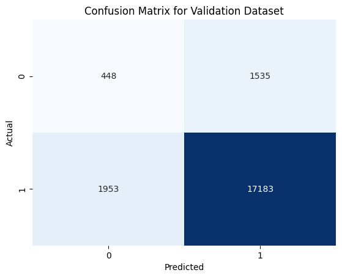

```python
# Fit model
xgb_best_model.fit(X_train_numpy, y_train_numpy)

# Evaluate the model on the training dataset with cross-validation
xgb_preds_train = cross_val_predict(xgb_best_model, X_train_numpy, y_train_numpy, cv=5)

# Predict on the validation dataset
xgb_preds_valid = xgb_best_model.predict(X_valid_numpy)

# Print the classification report for training and validation datasets
print("Performance on Training Dataset : \n\n", classification_report(y_train, xgb_preds_train))
print("Performance on Validation Dataset : \n\n", classification_report(y_valid, xgb_preds_valid))

# Compute and display the confusion matrix for the validation dataset
cm = confusion_matrix(y_valid, xgb_preds_valid)
sns.heatmap(cm, annot=True, fmt='d', cmap='Blues', cbar=False)

plt.xlabel('Predicted')
plt.ylabel('Actual')
plt.title('Confusion Matrix for Validation Dataset')
plt.show()
```

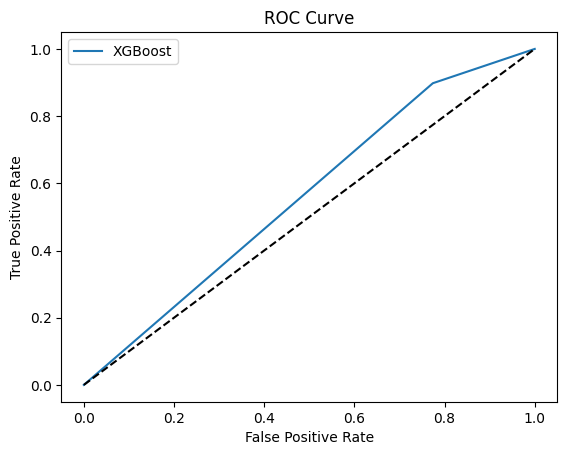

```
AUC Score: 0.5619306881275119
```

```python
# ROC plot for the XGBoost
tpr, fpr, thresholds = roc_curve(y_valid, xgb_preds_valid, pos_label=0)
plt.plot(fpr, tpr, label='XGBoost')
plt.plot([0, 1], [0, 1], 'k--')
plt.xlabel('False Positive Rate')
plt.ylabel('True Positive Rate')
plt.title('ROC Curve')
plt.legend()
plt.show()

print("AUC Score:", roc_auc_score(y_valid, xgb_preds_valid))
```

```python
# Generate the classification report as a dictionary
report = classification_report(y_valid, xgb_preds_valid, output_dict=True)

# Extract metrics from the report
accuracy = report["accuracy"]
recall_false = report["False"]["recall"]
f1_score_false = report["False"]["f1-score"]
f1_score_weighted = report["weighted avg"]["f1-score"]
f1_score_macro = report["macro avg"]["f1-score"]


# Save them in csv file
save_metrics_to_csv(
    model_name="xgb with imbalanced data",
    accuracy=accuracy,
    recall_false=recall_false,
    f1_score_false=f1_score_false,
    f1_score_weighted=f1_score_weighted,
    f1_score_macro=f1_score_macro,
    file_path='/content/drive/My Drive/IDS_model_metrics.csv'
)
```

## Neural Network

As a last model, we will implement a neural network. To be more precise, the MLPClassifier will be implemented. The MLPClassifier is a machine learning model in scikit-learn that uses a multilayer perceptron (MLP) neural network for classification tasks. It is a type of feedforward artificial neural network trained using backpropagation.

```python
# Setup default model
neuron = MLPClassifier(random_state=42)
neuron.fit(X_train, y_train)
neuron_preds_train = cross_val_predict(neuron, X_train, y_train, cv=5)
print(classification_report(y_train, neuron_preds_train))
```

```
              precision    recall  f1-score   support

       False       0.45      0.02      0.03      4414
        True       0.91      1.00      0.95     44861

    accuracy                           0.91     49275
   macro avg       0.68      0.51      0.49     49275
weighted avg       0.87      0.91      0.87     49275
```

As we can see, also the default neural network suffers strongly from the imbalanced dataset. While the recall for the insured group is 1 and the precision 0.91, the recall for the uninsured group is only 0.02, leading to a F1 score of 0.03.

We will now attempt to solve this problem by optimizing the parameters. The MLPClassifier has a great number of parameters. Several of them, such as the activation function or solving algorithm, do, however, not have a strong impact on the performance. We, therefore, decided to focus on the most powerful parameters - namely the number of hidden layers and neurons within those layers, the L2 regularization term alpha, and the learning rate. The number of hidden layers determines the depth of the neural network, while the number of neurons in each layer controls its capacity to learn complex patterns. The L2 regularization term (alpha) helps prevent overfitting by penalizing large weights, encouraging the model to generalize better. The learning rate controls how much the model's weights are adjusted during training, affecting the speed and stability of the learning process.

```python
# Define the parameter grid
parameter_grid = {
    'hidden_layer_sizes': [(100, 100, 100), (200,), (200, 200, 200), (300,), (300, 300, 300)],
    'alpha': [0.0001, 0.05, 0.2, 0.8],
    'learning_rate_init': [0.001, 0.05, 0.1]
}

# Initialize the MLPClassifier
neuron = MLPClassifier(early_stopping=True, random_state=42)

# Set up GridSearchCV with 3-fold cross-validation
grid_search = GridSearchCV(
    estimator=neuron,
    param_grid=parameter_grid,
    scoring=negative_class_recall_scorer,
    cv=3,  # 3-fold cross-validation
    verbose=1,  # Shows progress during the grid search
    n_jobs=-1  # Use all available cores for parallel processing
)

# Fit the grid search to the data
grid_search.fit(X_train, y_train)

# Best hyperparameters found
print("Best hyperparameters:", grid_search.best_params_)

# Best model from grid search
neuron_best_model = grid_search.best_estimator_
```

```
Fitting 3 folds for each of 60 candidates, totalling 180 fits
Best hyperparameters: {'alpha': 0.0001, 'hidden_layer_sizes': (200, 200, 200), 'learning_rate_init': 0.001}
```

The optimal hyperparameters for the MLPClassifier model were found to be an L2 regularization term (alpha) of 0.0001, a network structure with three hidden layers, each containing 200 neurons, and a learning rate of 0.001. This suggests that the model performs best with a relatively low regularization strength, allowing it to learn complex patterns without overfitting. The low amount of regularization may be necessary to adequately fit the uninsured cases. Furthermore, the results show that we need a complex model to fit our data as implied by the choice of a deep network with 200 neurons in each of the three hidden layers. This more complex model architecture is likely beneficial for capturing intricate relationships in the data. The low learning rate implies that the model's weights are adjusted more slowly during training, with smaller updates at each step. This can be beneficial because it allows the model to converge more smoothly to an optimal solution, reducing the risk of overshooting the minimum of the loss function. Furthermore, we fixed that our model will learn with early stopping. Early stopping is a technique used to halt training when the model's performance on a validation set starts to degrade since this indicates overfitting.

```python
# Run model with optimized parameters on training data
neuron_preds_train = cross_val_predict(neuron_best_model, X_train, y_train, cv=5)
# Print the classification report
print("Performance on Training Dataset : \n\n", classification_report(y_train, neuron_preds_train))
```

```
Performance on Training Dataset :

               precision    recall  f1-score   support

       False       0.16      0.00      0.00      4414
        True       0.91      1.00      0.95     44861

    accuracy                           0.91     49275
   macro avg       0.54      0.50      0.48     49275
weighted avg       0.84      0.91      0.87     49275
```

As we can see, the parameter tuning was not successful. In fact, the performance even decreased, which is probably due to variations in the random k-fold cross validation split. Despite the optimal parameters, the uninsured group has a recall, and therefore also a F1 score, of 0. In this form, the model does not provide any informational value at all. Considering that the MLPClassifier creates probabilities for each class, we will now tune the cutoff-score to produce better results.

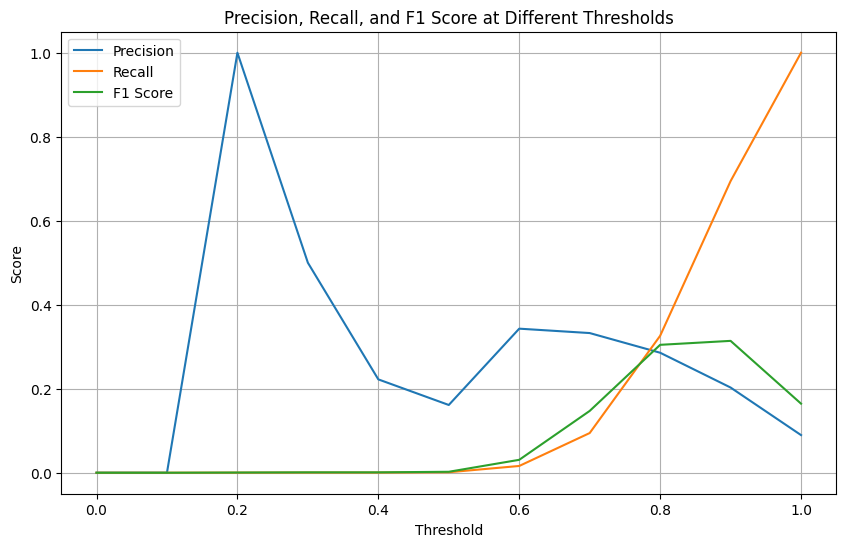

```python
# Get predicted probabilities for the positive class (1)
y_probs = cross_val_predict(neuron_best_model, X_train, y_train, cv=5, method='predict_proba')[:, 1]

# Define thresholds to test
thresholds = np.arange(0.0, 1.1, 0.1)
metrics = {'threshold': [], 'precision': [], 'recall': [], 'f1': []}

for threshold in thresholds:
    precision, recall, f1 = evaluate_threshold(threshold, y_train, y_probs)
    metrics['threshold'].append(threshold)
    metrics['precision'].append(precision)
    metrics['recall'].append(recall)
    metrics['f1'].append(f1)

# Plot the metrics
plt.figure(figsize=(10, 6))
plt.plot(metrics['threshold'], metrics['precision'], label='Precision')
plt.plot(metrics['threshold'], metrics['recall'], label='Recall')
plt.plot(metrics['threshold'], metrics['f1'], label='F1 Score')
plt.xlabel('Threshold')
plt.ylabel('Score')
plt.title('Precision, Recall, and F1 Score at Different Thresholds')
plt.legend()
plt.grid()
plt.show()
```

The plot shows us that the highest F1 score for the uninsured class is reached with a decision threshold of 0.9. This also allows us to maximize the recall of the uninsured group, which is our objective from a business point of view.

```
Classification Report with Threshold = 0.9 for Training Data:
              precision    recall  f1-score   support

       False       0.22      0.72      0.34      1983
        True       0.96      0.73      0.83     19136

    accuracy                           0.73     21119
   macro avg       0.59      0.73      0.58     21119
weighted avg       0.89      0.73      0.79     21119

Classification Report with Threshold = 0.9 for Validation Data:
              precision    recall  f1-score   support

       False       0.20      0.69      0.31      4414
        True       0.96      0.73      0.83     44861

    accuracy                           0.73     49275
   macro avg       0.58      0.71      0.57     49275
weighted avg       0.89      0.73      0.78     49275
```

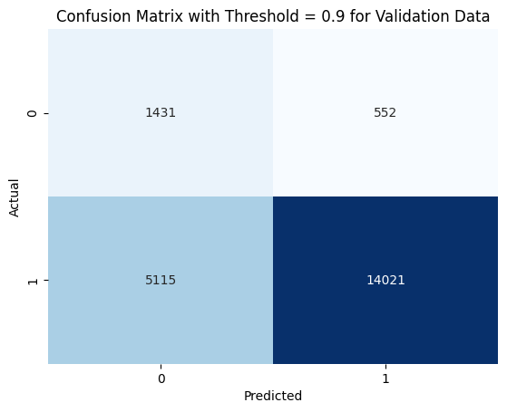

```python
# Apply the 0.9 decision threshold
neuron_preds_train_threshold = (y_probs >= 0.9).astype(int)
neuron_best_model.fit(X_train, y_train)
y_probs = neuron_best_model.predict_proba(X_valid)[:, 1]
neuron_preds_valid_threshold = (y_probs >= 0.9).astype(int)

# Print the classification report
print("Classification Report with Threshold = 0.9 for Training Data:")
print(classification_report(y_valid, neuron_preds_valid_threshold))
print("Classification Report with Threshold = 0.9 for Validation Data:")
print(classification_report(y_train, neuron_preds_train_threshold))

# Plot the Confusion Matrix
cm = confusion_matrix(y_valid, neuron_preds_valid_threshold)
sns.heatmap(cm, annot=True, fmt='d', cmap='Blues', cbar=False)

plt.xlabel('Predicted')
plt.ylabel('Actual')
plt.title('Confusion Matrix with Threshold = 0.9 for Validation Data')
plt.show()
```

As we can see, the performance with a threshold of 0.9 is a lot better. Although the recall for the insured group decreased, of course, we were able to increase the recall of the uninsured group to approximately 0.7 on both the training and validation dataset. This results in a F1 score of 0.3 for the uninsured group. Given that the F1 score was 0.0 before, this can be seen as a great improvement.

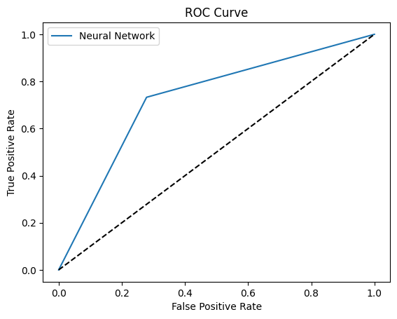

```
AUC Score: 0.7271683236228679
```

```python
# ROC plot for the Neural Network
tpr, fpr, thresholds = roc_curve(y_valid, neuron_preds_valid_threshold, pos_label=0)
plt.plot(fpr, tpr, label='Neural Network')
plt.plot([0, 1], [0, 1], 'k--')
plt.xlabel('False Positive Rate')
plt.ylabel('True Positive Rate')
plt.title('ROC Curve')
plt.legend()
plt.show()

print("AUC Score:", roc_auc_score(y_valid, neuron_preds_valid_threshold))
```

```python
# Generate the classification report as a dictionary
report = classification_report(y_valid, neuron_preds_valid_threshold, output_dict=True)

# Extract metrics from the report
accuracy = report["accuracy"]
recall_false = report["False"]["recall"]
f1_score_false = report["False"]["f1-score"]
f1_score_weighted = report["weighted avg"]["f1-score"]
f1_score_macro = report["macro avg"]["f1-score"]


# Save them in csv file
save_metrics_to_csv(
    model_name="neural network with imbalanced data",
    accuracy=accuracy,
    recall_false=recall_false,
    f1_score_false=f1_score_false,
    f1_score_weighted=f1_score_weighted,
    f1_score_macro=f1_score_macro,
    file_path='/content/drive/My Drive/IDS_model_metrics.csv'
)
```

# **Modeling with balanced data**

As we already pointed out, our target variable is distributed with a high imbalance. Only 10% of our sample consists of people without health insurance. This leads to issues such as the low recall score for the uninsured. To fight this issue and possibly increase model performance, we decided to employ oversampling to build a balanced training dataset. We will only oversample the uninsured in the training dataset and not in the validation and test dataset because the variable health insurance is also distributed unequally in reality. Therefore, our model should be validated and tested on a variable distribution comparable to the real word. In the training dataset, oversampling can, however, help to improve model performance. Oversampling means artificially increasing the representation of the minority class, typically through techniques like random sampling with replacement or synthetic data generation methods such as SMOTE (Synthetic Minority Over-sampling Technique). SMOTE mitigates the risk of oversampling bias compared to random sampling with replacement by generating synthetic samples rather than duplicating existing ones. Unlike random sampling, which simply replicates minority class instances and risks overfitting, SMOTE creates new samples by interpolating between existing minority instances. This approach preserves the distribution of the original data while introducing variability, reducing the likelihood of overfitting and improving the model's generalization to unseen data. Therefore, we employed a SMOTE approach.

## Oversampling Process

```python
# pip install imbalanced-learn

# Define oversampling and undersampling strategies
oversample = SMOTE(sampling_strategy=0.5)  # Increase minority class to 50%
undersample = RandomUnderSampler(sampling_strategy=1)  # Decrease majority class to 50%

# Combine oversampling and undersampling in a pipeline
steps = [('o', oversample), ('u', undersample)]
pipeline = Pipeline(steps=steps)

# Resample the training dataset
X_train_oversampled, y_train_oversampled = pipeline.fit_resample(X_train, y_train)

# Display the class distribution before and after resampling
print("Original training set class distribution:", Counter(y_train))
print("Resampled training set class distribution:", Counter(y_train_oversampled))
```

```
Original training set class distribution: Counter({True: 44861, False: 4414})
Resampled training set class distribution: Counter({False: 22430, True: 22430})
```

The output first shows the class distribution in the original training dataset. True (44861) represents people with health insurance. False (4414) represents people without health insurance (the minority class). As mentioned before, the minority class (uninsured) makes up only 10% of the dataset, leading to the class imbalance.

It also shows the class distribution after resampling. Both the majority (insured) and minority (uninsured) classes are now equally represented, with 22,430 samples in each class. Therefore, our oversampling was successful and we can now start building the models based on the balanced data.

## Logistic Regression

As with the imbalanced data, as a first model, we will set up a logistic regression.

```python
# Set up the default model
log_reg = LogisticRegression()
log_reg_preds_train = cross_val_predict(log_reg, X_train_oversampled, y_train_oversampled, cv=5)

# Print the classification report
print(classification_report(y_train_oversampled, log_reg_preds_train))
```

```
              precision    recall  f1-score   support

       False       0.78      0.80      0.79     22430
        True       0.79      0.77      0.78     22430

    accuracy                           0.78     44860
   macro avg       0.78      0.78      0.78     44860
weighted avg       0.78      0.78      0.78     44860
```

The default logistic regression already performs significantly better than the finetuned logistic regression based on the imbalanced dataset. While the accuracy is slightly lower with the balanced dataset, the model has a much more balanced performance when it comes to predicting the individual classes. Recall and precision are both relatively high for each class. This is represented by the high F1 score of 0.79. For comparison, the non-finetuned logistic regression based on the imbalanced dataset resulted in a recall of 0.01 and F1 score of 0.03 for the uninsured group. Even after finetuning the parameters and adjusting the class_weight parameter to incur higher penalties for misclassification for uninsured individuals, the model only reached a recall 0f 0.44 and F1 score of 0.35. In conclusion, the good performance of the default logistic regression shows how important and powerful oversampling is when it comes to imbalanced datasets. We will now finetune the model to optimize the performance.

```python
# Try different solving algorithms for the optimization problem
solvers = ["newton-cg", "lbfgs", "liblinear", "sag", "saga"]
train_recall = {}

for solver_name in solvers:

    log_reg = LogisticRegression(solver=solver_name)
    log_reg_preds_train = cross_val_predict(log_reg, X_train_oversampled, y_train_oversampled, cv=4)

    # Calculate the recall score
    train_recall[solver_name] = recall_score(y_train_oversampled, log_reg_preds_train, pos_label=0)

print("Recall: ", sorted(train_recall.items(), key=lambda x: x[1], reverse=True))
```

```
Recall:  [('saga', 0.7983504235399019), ('liblinear', 0.7977708426214891), ('newton-cg', 0.7975925100312082), ('sag', 0.7974587605884975), ('lbfgs', 0.7973250111457869)]
```

The differences between the performance of the solving algorithms is only minor. Nonetheless, we will stay with the best-performing algorithm ("saga"). We can see that the model performs differently based on the balanced data. With the imbalanced data, "lbfgs" was the best performing solver. Now, "lbfgs" is the worst algorithm. This highlights the importance of finetuning the parameters from scratch after oversampling the data.

```python
# Try different penalties
penalties = ["l1","l2"]

for penalty_name in penalties:
  log_reg = LogisticRegression(solver="saga", penalty=penalty_name)
  log_reg_preds_train = cross_val_predict(log_reg, X_train_oversampled, y_train_oversampled, cv=4)

  # Calculate recall score
  train_recall = recall_score(y_train_oversampled, log_reg_preds_train, pos_label=0)
  print(penalty_name, "recall:", train_recall)
```

```
l1 recall: 0.7983058403923317
l2 recall: 0.7983950066874721
```

```python
c_values = [0.1, 0.3, 0.5, 0.7, 1.0]
train_recall = {}

for c_float in c_values:

    log_reg = LogisticRegression(solver="saga", penalty="l1", C=c_float)
    log_reg_preds_train = cross_val_predict(log_reg, X_train_oversampled, y_train_oversampled, cv=4)

    # Calculate the recall score
    train_recall[c_float] = recall_score(y_train_oversampled, log_reg_preds_train, pos_label=0)

print("Train Recall: ", sorted(train_recall.items(), key=lambda x: x[1], reverse=True))
```

```
Train Recall:  [(0.1, 0.7988408381631743), (0.3, 0.798573339277753), (0.5, 0.7983950066874721), (0.7, 0.7983058403923317), (1.0, 0.7983058403923317)]
```

We can see that c = 0.1 optimizes the performance. This suggests that the model performs better with a higher level of regularization, which is controlled by a smaller value of c. This indicates that the model performs better when more emphasis is placed on avoiding complexity and fitting noise in the training data. It should be noted that the logistic regression model trained with the imbalanced data could was optimized with a c value of 1.0, meaning it performed better with a weaker form of regularization. This is likely due to the fact that it had to to be more sensitive to small variances in the data to be able to detect the few uninsured cases among all the insured cases. The oversampling reduced this need to fit to very small variations to identify a minority group.

```
Performance on Training Dataset :

               precision    recall  f1-score   support

       False       0.77      0.80      0.79     22430
        True       0.79      0.77      0.78     22430

    accuracy                           0.78     44860
   macro avg       0.78      0.78      0.78     44860
weighted avg       0.78      0.78      0.78     44860

Performance on Validation Dataset :

               precision    recall  f1-score   support

       False       0.21      0.60      0.31      1983
        True       0.95      0.77      0.85     19136

    accuracy                           0.75     21119
   macro avg       0.58      0.69      0.58     21119
weighted avg       0.88      0.75      0.80     21119
```

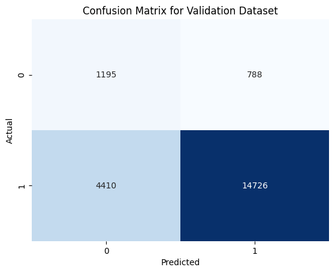

```python
# Final Model
log_reg = LogisticRegression(solver="saga", penalty="l1", C=0.1)
log_reg.fit(X_train_oversampled, y_train_oversampled)
log_reg_preds_train = cross_val_predict(log_reg, X_train_oversampled, y_train_oversampled, cv=5)
log_reg_preds_valid = log_reg.predict(X_valid)

# Print the classification report
print("Performance on Training Dataset : \n\n", classification_report(y_train_oversampled, log_reg_preds_train))
print("Performance on Validation Dataset : \n\n", classification_report(y_valid, log_reg_preds_valid))

# Plot the Confusion Matrix
cm = confusion_matrix(y_valid, log_reg_preds_valid)
sns.heatmap(cm, annot=True, fmt='d', cmap='Blues', cbar=False)

plt.xlabel('Predicted')
plt.ylabel('Actual')
plt.title("Confusion Matrix for Validation Dataset")
plt.show()
```

Our parameter finetuning did not significantly improve the performance on the training data. This is, however, not a great problem considering that the performance of the default model was already very good. Unfortunately, the performance on the validation dataset deviates strongly from the performance on the training data. While the accuracy is stable, the F1 score and its components are highly different, especially for the uninsured group, which is the focus of our project. The precision for the validation dataset and uninsured is only 0.21 in comparison to 0.78 and the recall 0.6 instead of 0.8, leading to a decrease of the F1 score by approximately 0.5 to 0.31. For the insured individuals, the precision increases from 0.79 to 0.95 while the recall remains nearly the same. This great difference in performance can be attributed to the fact that the model was trained on balanced data but is confronted with imbalanced data. Considering that the model will have to work with imbalanced data in the real world, it is, however, crucial to maintain the imbalance in the validation dataset.

Now that we have validated our model with imbalanced data, we should compare the performance with the performance of the model trained with imbalanced data again. The final model trained with imbalanced data achieved a recall of 0.44 and F1 score of 0.35 for the uninsured group. Therefore, it outperforms the model trained with balanced data when it comes to F1. This is due to the very low precision of the model trained with balanced data. This demonstrates that oversampling can enhance model performance, but has limitations when it comes to the generalizability to the imbalanced data of the real world. In conclusion, the logistic regression trained on balanced data only appears to perform significantly better, but actually performs worse when confronted with imbalanced data. At least when performance is measured by the F1 score. Nonetheless, it has to be mentioned that this only holds true for the finetuned logistic regression based on imbalanced data. The default model performed significantly worse than the logistic regression trained on balanced data. The greatest performance boost was given by the change of cutoff-score, which lead to performance superior to the model trained on balanced data.

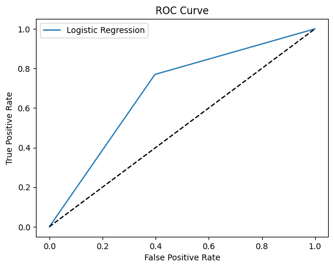

```
AUC Score: 0.6860833019208423
```

```python
# ROC plot for the Logistic Regression Model (Final Model)
tpr, fpr, thresholds = roc_curve(y_valid, log_reg_preds_valid, pos_label=0)
plt.plot(fpr, tpr, label='Logistic Regression')
plt.plot([0, 1], [0, 1], 'k--')
plt.xlabel('False Positive Rate')
plt.ylabel('True Positive Rate')
plt.title('ROC Curve')
plt.legend()
plt.show()

print("AUC Score:", roc_auc_score(y_valid, log_reg_preds_valid))
```

When it comes to the ROC curves and AUC score, the Logistic Regression model demonstrates a good performance with a clear separation from the diagonal line, indicating that it is better than random guessing. The AUC score of 0.69 is significantly higher than the AUC score of random guessing (0.5) and even slightly higher than the AUC score of the Logistic Regression trained with unbalanced data (0.66).

```python
# Generate the classification report as a dictionary
report = classification_report(y_valid, log_reg_preds_valid, output_dict=True)

# Extract metrics from the report
accuracy = report["accuracy"]
recall_false = report["False"]["recall"]
f1_score_false = report["False"]["f1-score"]
f1_score_weighted = report["weighted avg"]["f1-score"]
f1_score_macro = report["macro avg"]["f1-score"]


# Save them in csv file
save_metrics_to_csv(
    model_name="logistic regression with balanced data",
    accuracy=accuracy,
    recall_false=recall_false,
    f1_score_false=f1_score_false,
    f1_score_weighted=f1_score_weighted,
    f1_score_macro=f1_score_macro,
    file_path='/content/drive/My Drive/IDS_model_metrics.csv'
)
```

## K-Nearest Neighbor

We will now proceed to build a KNN model based on the balanced data.

```
{3: 0.9934462773071779, 5: 0.9895675434685689, 7: 0.9843513152028533, 9: 0.9776192599197503, 11: 0.9704413731609451, 13: 0.9641997325011146, 15: 0.9578689255461436, 17: 0.9525635309852876, 19: 0.9488631297369594, 21: 0.9451181453410611, 23: 0.9399019170753455, 25: 0.9356665180561747}
{3: 0.513363590519415, 5: 0.5799293998991427, 7: 0.6127080181543116, 9: 0.6263237518910741, 11: 0.6359051941502774, 13: 0.6419566313666163, 15: 0.6611195158850227, 17: 0.6727181038830056, 19: 0.6843166918809884, 21: 0.6863338376197681, 23: 0.6949067070095815, 25: 0.7014624306606152}
```

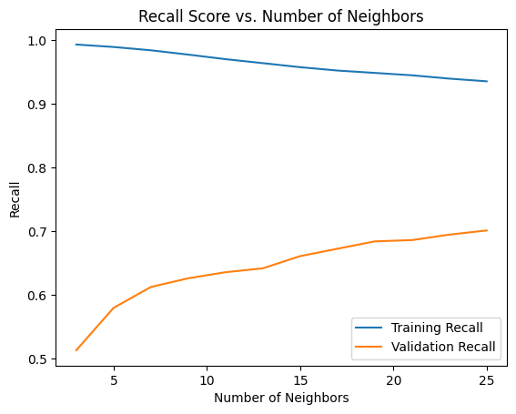

```python
k_neighbors = np.arange(3, 27, 2)
train_recall = {}
valid_recall = {}

for k in k_neighbors:
    knn = KNeighborsClassifier(n_neighbors=k, algorithm='kd_tree', metric='euclidean')
    knn.fit(X_train_oversampled, y_train_oversampled)
    knn_preds_train = knn.predict(X_train_oversampled)
    knn_preds_valid = knn.predict(X_valid)

    # Calculate the recall score
    train_recall[k] = recall_score(y_train_oversampled, knn_preds_train, pos_label=0)
    valid_recall[k] = recall_score(y_valid, knn_preds_valid, pos_label=0)

print(train_recall)
print(valid_recall)

plt.plot(k_neighbors, train_recall.values(), label='Training Recall')
plt.plot(k_neighbors, valid_recall.values(), label='Validation Recall')
plt.title('Recall Score vs. Number of Neighbors')
plt.xlabel('Number of Neighbors')
plt.ylabel('Recall')
plt.legend()
plt.show()
```

To choose a number of neighbors, we are using the Elbow Method. The performance on the validation dataset seems to stagnate at k = 25, wherefore we will choose this number. This is a relatively high number and represents a significant difference to the KNN model trained with imbalanced data, which showed the best performance with a small number of neighbors (k = 3). The difference in optimal k-values for the KNN models could be due to the way each dataset influences the model's performance. In the imbalanced dataset, the minority class (uninsured) is underrepresented, which can lead to the model focusing more on the majority class (insured) when making predictions, especially with higher values of k. A smaller k (such as 3) might be effective because it allows the model to capture the local structure of the minority class more effectively. On the other hand, the model trained on the oversampled dataset has a more balanced distribution of classes, which means the model is now able to give more attention to the minority class. With more balanced data, a higher k (such as 25) might perform better because it smooths out the decision boundaries, reducing the influence of noise and outliers. The higher k helps ensure that the model makes more stable predictions by considering a broader set of neighbors, which is beneficial when the data is more balanced.

Apart from that, we can see that the difference of the performance on the training and validation data is significantly higher when the model is trained on oversampled data. While the recall curves follow the same pattern when the model is trained with imbalanced data, the curves behave inversely for the model trained on oversampled data. With the number of k, the training recall decreases while the validation recall increases, until they both seem to stagnate. As with the Logistic Regression, this is due to the model not being familiar with the imbalanced nature of the validation dataset.

```
Performance on Training Dataset :

               precision    recall  f1-score   support

       False       0.72      0.91      0.80     22430
        True       0.88      0.65      0.74     22430

    accuracy                           0.78     44860
   macro avg       0.80      0.78      0.77     44860
weighted avg       0.80      0.78      0.77     44860

Performance on Validation Dataset :

               precision    recall  f1-score   support

       False       0.17      0.70      0.28      1983
        True       0.95      0.66      0.78     19136

    accuracy                           0.66     21119
   macro avg       0.56      0.68      0.53     21119
weighted avg       0.88      0.66      0.73     21119
```

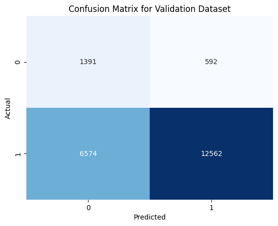

```python
# Set up Final Model
knn = KNeighborsClassifier(n_neighbors=25, algorithm='kd_tree', metric='euclidean')
knn.fit(X_train_oversampled, y_train_oversampled)

knn_preds_train = cross_val_predict(knn, X_train_oversampled, y_train_oversampled, cv=5)
knn_preds_valid = knn.predict(X_valid)

# Print the classification report
print("Performance on Training Dataset : \n\n", classification_report(y_train_oversampled, knn_preds_train))
print("Performance on Validation Dataset : \n\n", classification_report(y_valid, knn_preds_valid))

# Plot the Confusion matrix
cm = confusion_matrix(y_valid, knn_preds_valid)
sns.heatmap(cm, annot=True, fmt='d', cmap='Blues', cbar=False)

plt.xlabel('Predicted')
plt.ylabel('Actual')
plt.title('Confusion Matrix for Validation Dataset')
plt.show()
```

It is striking how strongly the performance of the model in predicting the validation instances changes based on the training data. The KNN model trained with imbalanced data had a recall of 0.1 and F1 score of 0.15, thereby being one of the worst-performing models. In comparison to this, the model trained with the oversampled data has a significantly better performance. The performance difference is a lot higher than for the Logistic Regression, for example. This might be due to the fact that the KNN model is a lazy learner - meaning it makes instance-based decisions based on the training instances rather than model-based decisions. Therefore, the change in training data may have a higher influence on the model performance than for an algorithm such as the Logistic Regression.

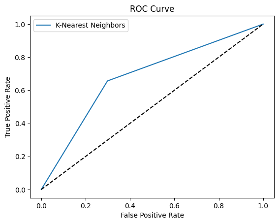

```
AUC Score: 0.6789607303804749
```

```python
# ROC plot for the KNN algorithm
tpr, fpr, thresholds = roc_curve(y_valid, knn_preds_valid, pos_label=0)
plt.plot(fpr, tpr, label='K-Nearest Neighbors')
plt.plot([0, 1], [0, 1], 'k--')
plt.xlabel('False Positive Rate')
plt.ylabel('True Positive Rate')
plt.title('ROC Curve')
plt.legend()
plt.show()

print("AUC Score:", roc_auc_score(y_valid, knn_preds_valid))
```

The ROC curve shows what we have already observed in the classification report. In contrast to the KNN model trained with imbalanced data (AUC score: 0.54), The KNN model trained with oversampled data outperforms random guessing by far. Therefore, we can conclude that the model is valuable and that oversampling is a very powerful tool when it comes to training KNN algorithms. This can be especially helpful with KNN models because KNN has only two parameters to tune - number of neighbours and distance metric. Therefore, we are limited in our possibilities to improve the performance of a KNN model and for imbalanced datasets, oversampling can be a highly important tool.

```python
# Generate the classification report as a dictionary
report = classification_report(y_valid, knn_preds_valid, output_dict=True)

# Extract metrics from the report
accuracy = report["accuracy"]
recall_false = report["False"]["recall"]
f1_score_false = report["False"]["f1-score"]
f1_score_weighted = report["weighted avg"]["f1-score"]
f1_score_macro = report["macro avg"]["f1-score"]


# Save them in csv file
save_metrics_to_csv(
    model_name="knn with balanced data",
    accuracy=accuracy,
    recall_false=recall_false,
    f1_score_false=f1_score_false,
    f1_score_weighted=f1_score_weighted,
    f1_score_macro=f1_score_macro,
    file_path='/content/drive/My Drive/IDS_model_metrics.csv'
)
```

## Bayesian Classifier

As a next model, we will implement a Bayesian Classifier.

```python
smoothing_values = [1e-1, 1e-2, 1e-3, 1e-4, 1e-5, 1e-6, 1e-7, 1e-8, 1e-9, 1e-10, 1e-11, 1e-12, 1e-13, 1e-14, 1e-15]
train_recall = {}

for smoothing in smoothing_values:
    # Set up a Bayesian Classifier and fit the model
    clf = GaussianNB(var_smoothing=smoothing)
    clf_preds_train = cross_val_predict(clf, X_train_oversampled, y_train_oversampled, cv=4)

    # Compute recall
    train_recall[smoothing] = recall_score(y_train_oversampled, clf_preds_train, pos_label=0)

print(train_recall)
```

[output not shown]

Considering that we had to change the prior probabilities and cutoff score for the first Bayesian Classifier mainly because of the imbalanced nature of the dataset, we will skip those parameters for the Bayesian classifier trained with the oversampled data.

```
Performance on Training Dataset :

               precision    recall  f1-score   support

       False       0.73      0.65      0.69     22430
        True       0.68      0.76      0.72     22430

    accuracy                           0.71     44860
   macro avg       0.71      0.71      0.70     44860
weighted avg       0.71      0.71      0.70     44860

Performance on Validation Dataset :

               precision    recall  f1-score   support

       False       0.20      0.56      0.29      1983
        True       0.94      0.76      0.84     19136

    accuracy                           0.74     21119
   macro avg       0.57      0.66      0.57     21119
weighted avg       0.87      0.74      0.79     21119
```

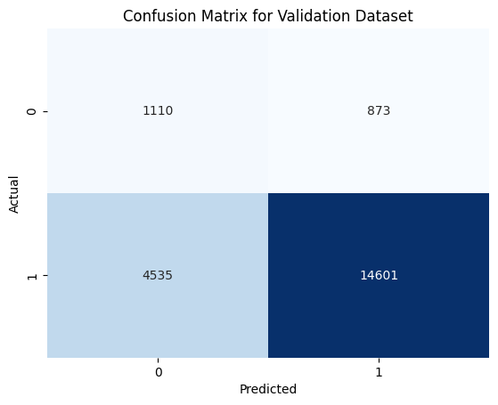

```python
# Model with correct smoothing parameter
clf = GaussianNB(var_smoothing=1e-4)
clf.fit(X_train_oversampled, y_train_oversampled)
clf_preds_train = cross_val_predict(clf, X_train_oversampled, y_train_oversampled, cv=5)
clf_preds_valid = clf.predict(X_valid)

# Print the classification report
print("Performance on Training Dataset : \n\n", classification_report(y_train_oversampled, clf_preds_train))
print("Performance on Validation Dataset : \n\n", classification_report(y_valid, clf_preds_valid))

# Plot the Confusion matrix
cm = confusion_matrix(y_valid, clf_preds_valid)
sns.heatmap(cm, annot=True, fmt='d', cmap='Blues', cbar=False)

plt.xlabel('Predicted')
plt.ylabel('Actual')
plt.title('Confusion Matrix for Validation Dataset')
plt.show()
```

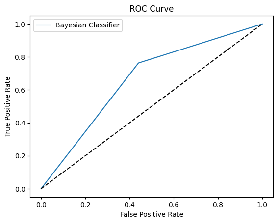

```
AUC Score: 0.6613850331285829
```

```python
# ROC plot for the Bayesian Classifier
tpr, fpr, thresholds = roc_curve(y_valid, clf_preds_valid, pos_label=0)
plt.plot(fpr, tpr, label='Bayesian Classifier')
plt.plot([0, 1], [0, 1], 'k--')
plt.xlabel('False Positive Rate')
plt.ylabel('True Positive Rate')
plt.title('ROC Curve')
plt.legend()
plt.show()

print("AUC Score:", roc_auc_score(y_valid, clf_preds_valid))
```

The AUC score and ROC curve show that the Bayesian Classifier based on oversampled data performs significantly better than random guessing when it comes to classifying uninsured individuals. The AUC score is approximately the same as the score of the Bayesian Classifier trained with imbalanced data, further highlighting the lack of improvement in performance on imbalanced data after oversampling.

```python
# Generate the classification report as a dictionary
report = classification_report(y_valid, clf_preds_valid, output_dict=True)

# Extract metrics from the report
accuracy = report["accuracy"]
recall_false = report["False"]["recall"]
f1_score_false = report["False"]["f1-score"]
f1_score_weighted = report["weighted avg"]["f1-score"]
f1_score_macro = report["macro avg"]["f1-score"]


# Save them in csv file
save_metrics_to_csv(
    model_name="bayesian classifier with balanced data",
    accuracy=accuracy,
    recall_false=recall_false,
    f1_score_false=f1_score_false,
    f1_score_weighted=f1_score_weighted,
    f1_score_macro=f1_score_macro,
    file_path='/content/drive/My Drive/IDS_model_metrics.csv'
)
```

## Decision Tree

As with the imbalanced data, we will also build a Decision Tree model for the oversampled data.

```python
tree_clf_over = DecisionTreeClassifier(random_state = 42)
tree_clf_over.fit(X_train_oversampled, y_train_oversampled)

tree_preds_train_over = cross_val_predict(tree_clf_over, X_train_oversampled, y_train_oversampled, cv=5)

# Print the classification report
print("Performance on Training Dataset : \n\n", classification_report(y_train_oversampled, tree_preds_train_over))
```

```
Performance on Training Dataset :

               precision    recall  f1-score   support

       False       0.81      0.80      0.81     22430
        True       0.81      0.81      0.81     22430

    accuracy                           0.81     44860
   macro avg       0.81      0.81      0.81     44860
weighted avg       0.81      0.81      0.81     44860
```

As with the models from before, the oversampled data leads to a very good performance in the cross-validation process. Both precision and recall are very high with 0.8 for both groups, leading to F1 scores of 0.8. For comparison, the Decision Tree trained with imbalanced data had a F1 score of 0.21 for the uninsured class and 0.91 for the insured class. As we can see, the oversampled data leads to a much more balanced performance.

```python
# Define a custom scorer for the recall of class 0
negative_class_recall_scorer = make_scorer(recall_score, pos_label=0)

# Define parameters to be tested
param_grid = {
    'max_depth': [5, 10, 20, 30, 40],
    'min_samples_split': [2, 5, 10, 15],
    'min_samples_leaf': [1, 2, 4, 8]
}

# Perform the grid search with the custom scorer
grid_search = GridSearchCV(tree_clf_over, param_grid, cv=5, scoring=negative_class_recall_scorer)
grid_search.fit(X_train_oversampled, y_train_oversampled)

# Retrieve the best parameters and model
best_params = grid_search.best_params_
tree_clf_over = grid_search.best_estimator_

print("Best Parameters:", best_params)
```

```
Best Parameters: {'max_depth': 20, 'min_samples_leaf': 2, 'min_samples_split': 2}
```

When compared to the best parameters for the Decision Tree model trained with the imbalanced data, the only difference is in the maximal depth. While the Tree for the imbalanced data performed best when it had a maximal depth of 40, the tree trained with the oversampled data performs best with a depth of 20. This might be attributed to the fact that the first tree had to be very sensititive to small variations in the data to the detect the few uninsured cases among all of the insured cases. The new tree might profit from the balanced nature of the dataset in the way that it can make more generalized decisions and still get enough uninsured samples in a leaf. As a next step, we will analyze the performance of the Decision Tree with the optimal parameters.

```
Performance on Training Dataset :

               precision    recall  f1-score   support

       False       0.79      0.83      0.81     22430
        True       0.82      0.78      0.80     22430

    accuracy                           0.80     44860
   macro avg       0.80      0.80      0.80     44860
weighted avg       0.80      0.80      0.80     44860

Performance on Validation Dataset :

               precision    recall  f1-score   support

       False       0.19      0.49      0.27      1983
        True       0.94      0.78      0.85     19136

    accuracy                           0.76     21119
   macro avg       0.56      0.64      0.56     21119
weighted avg       0.87      0.76      0.80     21119
```

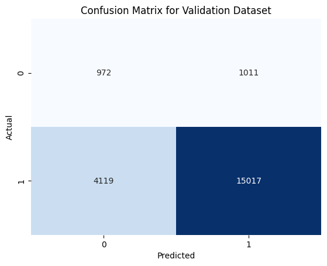

```python
tree_preds_train_over = cross_val_predict(tree_clf_over, X_train_oversampled, y_train_oversampled, cv=5)
tree_preds_valid_over = tree_clf_over.predict(X_valid)

# Print the classification report
print("Performance on Training Dataset : \n\n", classification_report(y_train_oversampled, tree_preds_train_over))
print("Performance on Validation Dataset : \n\n", classification_report(y_valid, tree_preds_valid_over))

# Print Confusion Matrix                                                                        # Plot the Confusion matrix
cm = confusion_matrix(y_valid, tree_preds_valid_over)
sns.heatmap(cm, annot=True, fmt='d', cmap='Blues', cbar=False)

plt.xlabel('Predicted')
plt.ylabel('Actual')
plt.title('Confusion Matrix for Validation Dataset')
plt.show()
```

As with all of the other models, we can see a great difference between the performance on the balanced training data and the performance on the imbalanced validation data. In comparison with the KNN model, however, not only the precision of the uninsured class decreases strongly but also the recall for this class. Nonetheless, the performance of the model trained with oversampled data is, also for the validation dataset, still significantly better than the performance of the model trained with the imbalanced data. The finetuned model on imbalanced data achieved a precision of 0.2, recall of 0.3 and a F1 score of 0.24 for the uninsured class. This shows again the different degrees of sensitivity to oversampling of the different models. So far, the Decision Tree is the only model next to the KNN which showed a superior performance with oversampled training data. When compared to the KNN, the performance improvement is, however, minor. As already explained earlier, this might be due to the fact that the KNN model is a lazy learner, whereas the Decision Tree is an eager learner.

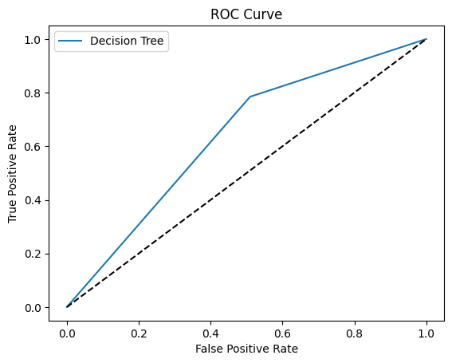

```
AUC Score: 0.6374588343520257
```

```python
# ROC plot for the Decision Tree
tpr, fpr, thresholds = roc_curve(y_valid, tree_preds_valid_over, pos_label=0)
plt.plot(fpr, tpr, label='Decision Tree')
plt.plot([0, 1], [0, 1], 'k--')
plt.xlabel('False Positive Rate')
plt.ylabel('True Positive Rate')
plt.title('ROC Curve')
plt.legend()
plt.show()

print("AUC Score:", roc_auc_score(y_valid, tree_preds_valid_over))
```

Similar to the classification report, the ROC curve shows the performance improvement in comparison to the Decision Tree trained with imbalanced data. The AUC score increased from 0.59 to 0.64, enhancing the outperformance of random guessing.

```python
# Generate the classification report as a dictionary
report = classification_report(y_valid, tree_preds_valid_over, output_dict=True)

# Extract metrics from the report
accuracy = report["accuracy"]
recall_false = report["False"]["recall"]
f1_score_false = report["False"]["f1-score"]
f1_score_weighted = report["weighted avg"]["f1-score"]
f1_score_macro = report["macro avg"]["f1-score"]


# Save them in csv file
save_metrics_to_csv(
    model_name="decision tree with balanced data",
    accuracy=accuracy,
    recall_false=recall_false,
    f1_score_false=f1_score_false,
    f1_score_weighted=f1_score_weighted,
    f1_score_macro=f1_score_macro,
    file_path='/content/drive/My Drive/IDS_model_metrics.csv'
)
```

## Random Forest

We will now implement a Random Forest to profit from the advantages of Ensemble methods when it comes to Decision Trees.

```python
# Set up default model
rf_clf_over = RandomForestClassifier(random_state = 42)
tree_preds_train_over = cross_val_predict(rf_clf_over, X_train_oversampled, y_train_oversampled, cv=5)

# Print the classification report
print("Performance on Training Dataset : \n\n", classification_report(y_train_oversampled, tree_preds_train_over))
```

```
Performance on Training Dataset :

               precision    recall  f1-score   support

       False       0.87      0.86      0.87     22430
        True       0.86      0.87      0.87     22430

    accuracy                           0.87     44860
   macro avg       0.87      0.87      0.87     44860
weighted avg       0.87      0.87      0.87     44860
```

```python
n_trees = [5, 10, 20, 50, 100, 200]
train_recall = {}

for n in n_trees:
    # Set up Random Forest and fit the model
    rf = RandomForestClassifier(n_estimators=n, max_depth = 20, min_samples_leaf= 2, min_samples_split= 5)
    rf_preds_train_over = cross_val_predict(rf, X_train_oversampled, y_train_oversampled, cv=4)

    # Compute recall
    train_recall[n] = recall_score(y_train_oversampled, rf_preds_train_over, pos_label=0)

print(train_recall)
```

```
{5: 0.837940258582256, 10: 0.8465893892108783, 20: 0.8507356219349086, 50: 0.8544360231832367, 100: 0.8555951850200624, 200: 0.8571110120374499}
```

```
Performance on Training Dataset :

               precision    recall  f1-score   support

       False       0.86      0.86      0.86     22430
        True       0.86      0.86      0.86     22430

    accuracy                           0.86     44860
   macro avg       0.86      0.86      0.86     44860
weighted avg       0.86      0.86      0.86     44860

Performance on Validation Dataset :

               precision    recall  f1-score   support

       False       0.27      0.44      0.33      1983
        True       0.94      0.88      0.91     19136

    accuracy                           0.84     21119
   macro avg       0.60      0.66      0.62     21119
weighted avg       0.87      0.84      0.85     21119
```

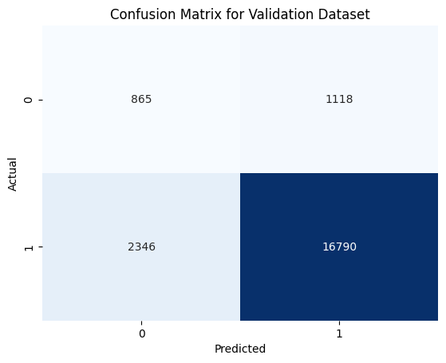

```python
# Set up final model
rf_over = RandomForestClassifier(n_estimators=100, max_depth = 20, min_samples_leaf= 2, min_samples_split= 5, random_state = 42)
rf_over.fit(X_train_oversampled,y_train_oversampled)
rf_preds_train_over = cross_val_predict(rf_over, X_train_oversampled, y_train_oversampled, cv=5)
rf_preds_valid_over = rf_over.predict(X_valid)

# Print the classification report
print("Performance on Training Dataset : \n\n", classification_report(y_train_oversampled, rf_preds_train_over))
print("Performance on Validation Dataset : \n\n", classification_report(y_valid, rf_preds_valid_over))

# Print Confusion Matrix
cm = confusion_matrix(y_valid, rf_preds_valid_over)
sns.heatmap(cm, annot=True, fmt='d', cmap='Blues', cbar=False)

plt.xlabel('Predicted')
plt.ylabel('Actual')
plt.title('Confusion Matrix for Validation Dataset')
plt.show()
```

As expected, the performance on the imbalanced validation dataset is worse than on the training data. We can see the increase in performance for the insured class as well as the strong decrease in performance for the uninsured class we have seen before. Nonetheless, the Random Forest trained with oversampled data outperforms the Random Forest trained with imbalanced data. While the precision is approximately the same, the recall is 0.24 and F1 score 0.11 points higher. This is in line with our findings of the Decision Tree model, which also achieved a strong performance boost with oversampling. Naturally, if one tree performs better, an ensemble of trees will also perform better.

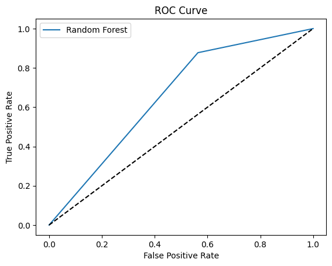

```
AUC Score: 0.6568058060824703
```

```python
# ROC plot for the Random Forest
tpr, fpr, thresholds = roc_curve(y_valid, rf_preds_valid_over, pos_label=0)
plt.plot(fpr, tpr, label='Random Forest')
plt.plot([0, 1], [0, 1], 'k--')
plt.xlabel('False Positive Rate')
plt.ylabel('True Positive Rate')
plt.title('ROC Curve')
plt.legend()
plt.show()

print("AUC Score:", roc_auc_score(y_valid, rf_preds_valid_over))
```

The ROC curve visualizes what we have seen in the classification report - oversampling increased the AUC score from 0.57 to 0.66 so that the model clearly outperforms random guessing.

```python
# Generate the classification report as a dictionary
report = classification_report(y_valid, rf_preds_valid_over, output_dict=True)

# Extract metrics from the report
accuracy = report["accuracy"]
recall_false = report["False"]["recall"]
f1_score_false = report["False"]["f1-score"]
f1_score_weighted = report["weighted avg"]["f1-score"]
f1_score_macro = report["macro avg"]["f1-score"]


# Save them in csv file
save_metrics_to_csv(
    model_name="random forest with balanced data",
    accuracy=accuracy,
    recall_false=recall_false,
    f1_score_false=f1_score_false,
    f1_score_weighted=f1_score_weighted,
    f1_score_macro=f1_score_macro,
    file_path='/content/drive/My Drive/IDS_model_metrics.csv'
)
```

## Support Vector Machine (SVM)

In accordance with our approach to training models with imbalanced data, we will now proceed to train a SVM model.

```python
# Set up default model
svm = SVC()
svm_preds_train = cross_val_predict(svm, X_train_oversampled, y_train_oversampled, cv=5)
print(classification_report(y_train_oversampled, svm_preds_train))
```

```
              precision    recall  f1-score   support

       False       0.76      0.82      0.78     22430
        True       0.80      0.74      0.77     22430

    accuracy                           0.78     44860
   macro avg       0.78      0.78      0.78     44860
weighted avg       0.78      0.78      0.78     44860
```

Unsurprisingly, the SVM model trained on the oversampled data shows a very good performance - just as the other models. When using the oversampled data, all of the scores (precision, recall, and F1) are higher than 0.7 for both groups. This results in an accuracy of 0.78. The performance improvement is especially noteworthy when considering that the default SVM trained with imbalanced data had a recall and precision of 0 for the uninsured group (meaning the model did not classify any instance as uninsured). We can, therefore, state that oversampling is a powerful technique for SVM models.

We will now perform a Grid Search with one quarter of the training data to find the best parameters for the model. Before opting for this approach, we already attempted other methods for finding the best parameters, which require less computing power than Grid Search (e.g. Randomized Search and Bayesian methods). Although these methods require less computing power, using the complete training data with them still resulted in extensive runtimes. Therefore, we decided to do the exhaustive Grid Search and use only a fraction of the training data. Although we were able to run a Grid Search with half of the training data for the imbalanced data, the Grid Search with balanced training data proved more computationally intensive, wherefore we had to reduce the fraction to 0.25 instead of 0.5.

```python
# Combine X and y to shuffle them together to ensure that we have 0s and 1s in each part
combined = np.column_stack((X_train_oversampled, y_train_oversampled))
np.random.shuffle(combined)

# Split back into X and y
X_train_shuffled = combined[:, :-1]
y_train_shuffled = combined[:, -1]

# Slice the first quarter of the training data to reduce computational complexity
quarter_X_train = X_train_shuffled[:len(X_train)//4]
quarter_y_train = y_train_shuffled[:len(y_train)//4]

# Convert boolean values to integers (0 and 1) in half_y_train
quarter_y_train = quarter_y_train.astype(int)
```

```python
# Define a custom scorer for the recall of class 0
negative_class_recall_scorer = make_scorer(recall_score, pos_label=0)

# Define parameter grid
param_grid = {'C': [0.1, 1, 10, 100, 1000, 1500, 2000],
              'gamma': [1, 0.1, 0.01, 0.001, 0.0001],
              'kernel': ['rbf']}

# Initialize GridSearchCV with the custom scorer and parameter grid
grid = GridSearchCV(SVC(), param_grid, cv=5, scoring=negative_class_recall_scorer)

# Fit the model for grid search using only the first half of the training data
grid.fit(quarter_X_train, quarter_y_train)

# Retrieve the best parameters and model
best_params = grid.best_params_
svm = grid.best_estimator_

print("Best Parameters:", best_params)
```

```
Best Parameters: {'C': 10, 'gamma': 0.1, 'kernel': 'rbf'}
```

The parameters optimizing the model performance are significantly different from the finetuned parameters for the SVM trained with imbalanced data - especially the value of C is a lot lower. While the optimal C was 1000 and the optimal gamma 0.1 for imbalanced data, our model with oversampled training data is optimized with a C of 10 and gamma of 0.1.

A lower C results in a lower penalty for misclassifying a data point, leading to a less complex decision boundary. While the SVM based on imbalanced data performed better when prioritizing precision over margin maximization, we can now see the opposite case. This speaks in favor of our assumption that the high value of C was necessary due to the imbalanced nature of the dataset.

```
Performance on Training Dataset :

               precision    recall  f1-score   support

       False       0.96      0.14      0.24     22430
        True       0.54      0.99      0.70     22430

    accuracy                           0.57     44860
   macro avg       0.75      0.57      0.47     44860
weighted avg       0.75      0.57      0.47     44860

Performance on Validation Dataset :

               precision    recall  f1-score   support

       False       0.22      0.02      0.04      1983
        True       0.91      0.99      0.95     19136

    accuracy                           0.90     21119
   macro avg       0.57      0.51      0.49     21119
weighted avg       0.84      0.90      0.86     21119
```

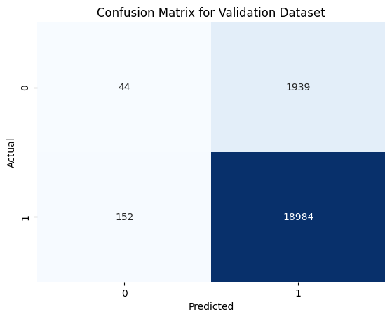

```python
# Set up finetuned model
svm.fit(X_train_oversampled, y_train_oversampled)
svm_preds_train = cross_val_predict(svm, X_train_oversampled, y_train_oversampled, cv=5)
svm_preds_valid = svm.predict(X_valid)

# Print classification report
print("Performance on Training Dataset : \n\n", classification_report(y_train_oversampled, svm_preds_train))
print("Performance on Validation Dataset : \n\n", classification_report(y_valid, svm_preds_valid))

# Plot the confusion matrix
cm = confusion_matrix(y_valid, svm_preds_valid)
sns.heatmap(cm, annot=True, fmt='d', cmap='Blues', cbar=False)

plt.xlabel('Predicted')
plt.ylabel('Actual')
plt.title('Confusion Matrix for Validation Dataset')
plt.show()
```

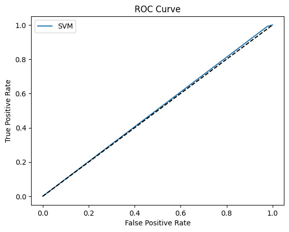

```
AUC Score: 0.5071227296569334
```

```python
# ROC plot for SVM
tpr, fpr, thresholds = roc_curve(y_valid, svm_preds_valid, pos_label=0)
plt.plot(fpr, tpr, label='SVM')
plt.plot([0, 1], [0, 1], 'k--')
plt.xlabel('False Positive Rate')
plt.ylabel('True Positive Rate')
plt.title('ROC Curve')
plt.legend()
plt.show()

print("AUC Score:", roc_auc_score(y_valid, svm_preds_valid))
```

The ROC curve visualizes what we could already see in the classification report. The model does not perform better than random guessing and is, therefore, one of the worst models tested and does not give valuable information.

```python
# Generate the classification report as a dictionary
report = classification_report(y_valid, svm_preds_valid, output_dict=True)

# Extract metrics from the report
accuracy = report["accuracy"]
recall_false = report["False"]["recall"]
f1_score_false = report["False"]["f1-score"]
f1_score_weighted = report["weighted avg"]["f1-score"]
f1_score_macro = report["macro avg"]["f1-score"]


# Save them in csv file
save_metrics_to_csv(
    model_name="svm with balanced data",
    accuracy=accuracy,
    recall_false=recall_false,
    f1_score_false=f1_score_false,
    f1_score_weighted=f1_score_weighted,
    f1_score_macro=f1_score_macro,
    file_path='/content/drive/My Drive/IDS_model_metrics.csv'
)
```

## XGBoost (Extreme Gradient Boosting)

Now we will implement the XGBoost model with the oversampled data as training data.

```python
# Convert to numpy array
X_train_oversampled_numpy = X_train_oversampled.to_numpy()
y_train_oversampled_numpy = y_train_oversampled.to_numpy()
X_valid_numpy = X_valid.to_numpy()

# Set up the default model
xgb_classifier = xgb.XGBClassifier(
    objective="binary:logistic",
    random_state=42)

xgb_preds_train = cross_val_predict(xgb_classifier, X_train_oversampled_numpy, y_train_oversampled_numpy, cv=5)

print(classification_report(y_train_oversampled, xgb_preds_train))
```

```
              precision    recall  f1-score   support

       False       0.91      0.81      0.85     22430
        True       0.83      0.92      0.87     22430

    accuracy                           0.86     44860
   macro avg       0.87      0.86      0.86     44860
weighted avg       0.87      0.86      0.86     44860
```

```python
# Define a custom scorer for the weighted average F1 score
weighted_avg_f1_scorer = make_scorer(f1_score, average='weighted')

# Set up the XGBClassifier
xgb_classifier = xgb.XGBClassifier(
    objective="binary:logistic",
    random_state=42
)

# Define the parameter distributions for RandomizedSearch
param_distributions = {
    'learning_rate': [0.05, 0.2, 0.3, 0.4, 0.6, 0.8],
    'max_depth': list(range(3, 11, 2)),
    'gamma': [0, 0.5, 1],
    'subsample': [0.1, 0.3, 0.5, 1.0],
    'lambda': [1e-5, 0.1, 1, 100],
    'alpha': [1e-5, 0.1, 1, 100]
}

# Set up RandomizedSearchCV with 3-fold cross-validation
random_search = RandomizedSearchCV(
    estimator=xgb_classifier,
    param_distributions=param_distributions,
    scoring=weighted_avg_f1_scorer,  # Optimize for weighted average F1 score
    cv=3,  # 3-fold cross-validation
    verbose=1,  # Shows progress during the random search
    n_jobs=-1,  # Use all available cores for parallel processing
    n_iter=50,  # Number of parameter settings that are sampled
    random_state=42  # Ensures reproducibility of the search
)

# Fit the randomized search to the oversampled data
random_search.fit(X_train_oversampled_numpy, y_train_oversampled_numpy)

# Best hyperparameters found
print("Best hyperparameters:", random_search.best_params_)

# Best model from randomized search
xgb_best_model_over = random_search.best_estimator_
```

```
Fitting 3 folds for each of 50 candidates, totalling 150 fits
Best hyperparameters: {'subsample': 1.0, 'max_depth': 9, 'learning_rate': 0.4, 'lambda': 100, 'gamma': 0, 'alpha': 1}
```

When comparing the optimal hyperparameters to the optimal hyperparameters of the XGBoost model for the imbalanced data, the biggest differences can be seen in the subsample size, lambda, and alpha. The subsample parameter is now 1 instead of 0.01, lambda 100 instead of 1e-05, and gamma 0 instead of 1. An increase of subsample value indicates that a larger fraction of the training data is used in each boosting iteration, which decreases bias but can also increase the risk of overfitting. A higher lambda strengthens regularization to reduce overfitting, while a lower gamma allows splits with smaller gains, increasing model flexibility.

```
Performance on Oversampled Training Dataset:

              precision    recall  f1-score   support

       False       0.91      0.81      0.86     22430
        True       0.83      0.92      0.87     22430

    accuracy                           0.87     44860
   macro avg       0.87      0.87      0.86     44860
weighted avg       0.87      0.87      0.86     44860


Performance on Validation Dataset:

              precision    recall  f1-score   support

       False       0.31      0.32      0.32      1983
        True       0.93      0.93      0.93     19136

    accuracy                           0.87     21119
   macro avg       0.62      0.62      0.62     21119
weighted avg       0.87      0.87      0.87     21119
```

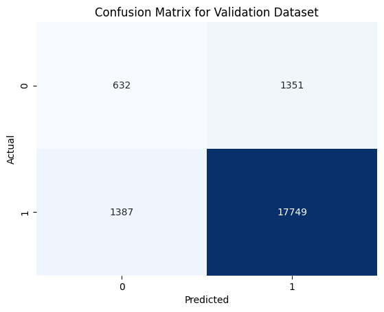

```python
# Evaluate the model on the oversampled training dataset with cross-validation
xgb_preds_train = cross_val_predict(xgb_best_model_over, X_train_oversampled_numpy, y_train_oversampled_numpy, cv=5)

# Predict on the validation dataset
xgb_preds_valid = xgb_best_model_over.predict(X_valid_numpy)

# Print the classification report for the training and validation datasets
print("Performance on Oversampled Training Dataset:\n")
print(classification_report(y_train_oversampled_numpy, xgb_preds_train))

print("\nPerformance on Validation Dataset:\n")
print(classification_report(y_valid, xgb_preds_valid))

# Compute and display the confusion matrix for the validation dataset
cm = confusion_matrix(y_valid, xgb_preds_valid)
sns.heatmap(cm, annot=True, fmt='d', cmap='Blues', cbar=False)

plt.xlabel('Predicted')
plt.ylabel('Actual')
plt.title('Confusion Matrix for Validation Dataset')
plt.show()
```

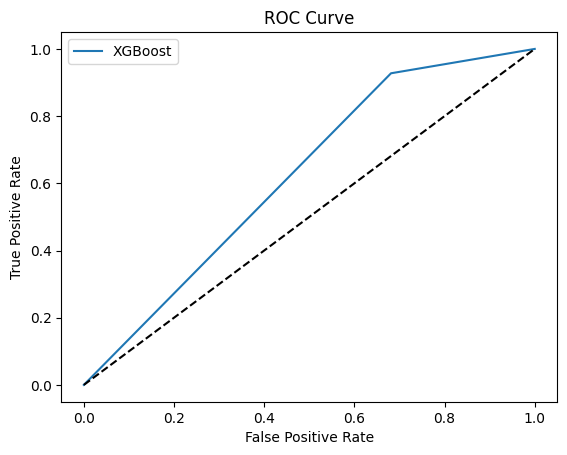

```
AUC Score: 0.6231139197181056
```

```python
tpr,fpr, thresholds = roc_curve(y_valid, xgb_preds_valid, pos_label=0)
plt.plot(fpr, tpr, label='XGBoost')
plt.plot([0, 1], [0, 1], 'k--')
plt.xlabel('False Positive Rate')
plt.ylabel('True Positive Rate')
plt.title('ROC Curve')
plt.legend()
plt.show()

print("AUC Score:", roc_auc_score(y_valid, xgb_preds_valid))
```

The AUC score and ROC curve reflects the findings from the classification report. While the performance is not exceptionally good, it is acceptable considering the difficulty of the data imbalance.

```python
# Generate the classification report as a dictionary
report = classification_report(y_valid, xgb_preds_valid, output_dict=True)

# Extract metrics from the report
accuracy = report["accuracy"]
recall_false = report["False"]["recall"]
f1_score_false = report["False"]["f1-score"]
f1_score_weighted = report["weighted avg"]["f1-score"]
f1_score_macro = report["macro avg"]["f1-score"]


# Save them in csv file
save_metrics_to_csv(
    model_name="xgb with balanced data",
    accuracy=accuracy,
    recall_false=recall_false,
    f1_score_false=f1_score_false,
    f1_score_weighted=f1_score_weighted,
    f1_score_macro=f1_score_macro,
    file_path='/content/drive/My Drive/IDS_model_metrics.csv'
)
```

## Neural Network

We will now setup the MLPClassifier with the oversampled training data.

```python
# Setup default model
neuron = MLPClassifier(random_state=42)
neuron.fit(X_train_oversampled, y_train_oversampled)
neuron_preds_train = cross_val_predict(neuron, X_train_oversampled, y_train_oversampled, cv=5)
print(classification_report(y_train_oversampled, neuron_preds_train))
```

```
              precision    recall  f1-score   support

       False       0.78      0.80      0.79     22430
        True       0.79      0.77      0.78     22430

    accuracy                           0.79     44860
   macro avg       0.79      0.79      0.79     44860
weighted avg       0.79      0.79      0.79     44860
```

```python
# Define the parameter grid
parameter_grid = {
    'hidden_layer_sizes': [(100, 100, 100), (200,), (200, 200, 200), (300,), (300, 300, 300)],
    'alpha': [0.0001, 0.05, 0.2, 0.8],
    'learning_rate_init': [0.001, 0.05, 0.1]
}

# Initialize the MLPClassifier
neuron = MLPClassifier(early_stopping=True, random_state=42)

# Set up GridSearchCV with 3-fold cross-validation
grid_search = GridSearchCV(
    estimator=neuron,
    param_grid=parameter_grid,
    scoring=negative_class_recall_scorer,
    cv=3,  # 3-fold cross-validation
    verbose=1,  # Shows progress during the grid search
    n_jobs=-1  # Use all available cores for parallel processing
)

# Fit the grid search to the data
grid_search.fit(X_train_oversampled, y_train_oversampled)

# Best hyperparameters found
print("Best hyperparameters:", grid_search.best_params_)

# Best model from grid search
neuron_best_model = grid_search.best_estimator_
```

```
Fitting 3 folds for each of 60 candidates, totalling 180 fits
Best hyperparameters: {'alpha': 0.0001, 'hidden_layer_sizes': (200, 200, 200), 'learning_rate_init': 0.001}
```

Interestingly, the optimal hyperparameters did not change based on the oversampling of the data. Therefore, we will implement the exact same model as before and an explanation of the parameters and possible reasoning behind their values can be found in the according section about the neural network trained with imbalanced data.

```python
# Run model with optimized parameters on training data
neuron_preds_train = cross_val_predict(neuron_best_model, X_train_oversampled, y_train_oversampled, cv=5)
# Print the classification report
print("Performance on Training Dataset : \n\n", classification_report(y_train_oversampled, neuron_preds_train))
```

```
Performance on Training Dataset :

               precision    recall  f1-score   support

       False       0.84      0.85      0.84     22430
        True       0.85      0.84      0.84     22430

    accuracy                           0.84     44860
   macro avg       0.84      0.84      0.84     44860
weighted avg       0.84      0.84      0.84     44860
```

In contrast to the case with imbalanced data, parameter tuning helped increasing the model performance. It not only improved the recall and precision of the uninsured class, but also of the insured class. Ultimately, we were able to reach a F1 score and accuracy of 0.84 for both classes.

```
Classification Report for Validation Data:
              precision    recall  f1-score   support

       False       0.21      0.44      0.28      1983
        True       0.93      0.83      0.88     19136

    accuracy                           0.79     21119
   macro avg       0.57      0.63      0.58     21119
weighted avg       0.87      0.79      0.82     21119
```

[figure not shown]

```python
# Predict validation data
neuron_best_model.fit(X_train_oversampled, y_train_oversampled)
neuron_preds_valid = neuron_best_model.predict(X_valid)

# Print the classification report
print("Classification Report for Validation Data:")
print(classification_report(y_valid, neuron_preds_valid))

# Plot the Confusion Matrix
cm = confusion_matrix(y_valid, neuron_preds_valid)
sns.heatmap(cm, annot=True, fmt='d', cmap='Blues', cbar=False)

plt.xlabel('Predicted')
plt.ylabel('Actual')
plt.title('Confusion Matrix with Threshold = 0.9 for Validation Data')
plt.show()
```

The performance on the imbalanced validation dataset is relatively similar to the performance of the MLPClassifier trained with imbalanced data and a threshold of 0.9. By training with the oversampled data, we did, however, manage to not need to tune the decision threshold anymore.

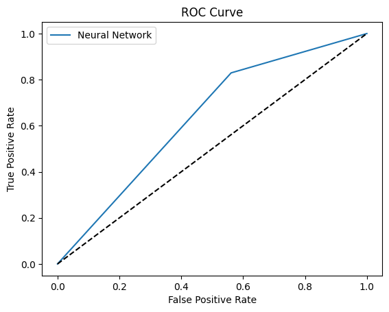

```
AUC Score: 0.634028060630746
```

```python
# ROC plot for the Neural Network
tpr, fpr, thresholds = roc_curve(y_valid, neuron_preds_valid, pos_label=0)
plt.plot(fpr, tpr, label='Neural Network')
plt.plot([0, 1], [0, 1], 'k--')
plt.xlabel('False Positive Rate')
plt.ylabel('True Positive Rate')
plt.title('ROC Curve')
plt.legend()
plt.show()

print("AUC Score:", roc_auc_score(y_valid, neuron_preds_valid))
```

```python
# Generate the classification report as a dictionary
report = classification_report(y_valid, neuron_preds_valid, output_dict=True)

# Extract metrics from the report
accuracy = report["accuracy"]
recall_false = report["False"]["recall"]
f1_score_false = report["False"]["f1-score"]
f1_score_weighted = report["weighted avg"]["f1-score"]
f1_score_macro = report["macro avg"]["f1-score"]


# Save them in csv file
save_metrics_to_csv(
    model_name="neural network with balanced data",
    accuracy=accuracy,
    recall_false=recall_false,
    f1_score_false=f1_score_false,
    f1_score_weighted=f1_score_weighted,
    f1_score_macro=f1_score_macro,
    file_path='/content/drive/My Drive/IDS_model_metrics.csv'
)
```

# Final Comparison of the Models

As a last step, we will compare the performance metrics of all our models to decide on our final model.

```python
# Mount Google Drive
drive.mount('/content/drive')
file_path='/content/drive/My Drive/IDS_model_metrics.csv'
metrics_df = pd.read_csv(file_path)

# Displaying the metrics
# Rounding values to two decimal places
metrics_df = metrics_df.round(2)

# Sorting by Macro Avg F1 Score in descending order
metrics_df = metrics_df.sort_values(by="Macro Avg F1 Score", ascending=False).reset_index(drop=True)

# Fix typo in the csv file based on multiple conditions
metrics_df.loc[
    (metrics_df['Model Name'] == "knn with imbalanced data") &
    (metrics_df['Accuracy'] == 0.66) &
    (metrics_df['Recall (False Group)'] == 0.70) &
    (metrics_df['F1 Score (False Group)'] == 0.28) &
    (metrics_df['Weighted Avg F1 Score'] == 0.73) &
    (metrics_df['Macro Avg F1 Score'] == 0.53),
    'Model Name'
] = "knn with balanced data"

# Styling the dataframe with color-coding
styled_df = metrics_df.style.background_gradient(
    cmap="RdYlGn", subset=["Macro Avg F1 Score"]
).format(precision=2)

styled_df
```

|  | Model Name | Accuracy | Recall (False Group) | F1 Score (False Group) | Weighted Avg F1 Score | Macro Avg F1 Score |
| --- | --- | --- | --- | --- | --- | --- |
| 0 | random forest with balanced data | 0.84 | 0.44 | 0.33 | 0.85 | 0.62 |
| 1 | xgb with balanced data | 0.87 | 0.32 | 0.32 | 0.87 | 0.62 |
| 2 | neural network with imbalanced data | 0.73 | 0.72 | 0.34 | 0.79 | 0.58 |
| 3 | logistic regression with balanced data | 0.75 | 0.60 | 0.31 | 0.80 | 0.58 |
| 4 | neural network with balanced data | 0.79 | 0.44 | 0.28 | 0.82 | 0.58 |
| 5 | decision tree with imbalanced data | 0.83 | 0.30 | 0.24 | 0.84 | 0.57 |
| 6 | random forest with imbalanced data | 0.87 | 0.19 | 0.22 | 0.86 | 0.57 |
| 7 | bayesian classifier with balanced data | 0.74 | 0.56 | 0.29 | 0.79 | 0.57 |
| 8 | xgb with imbalanced data | 0.83 | 0.23 | 0.20 | 0.84 | 0.56 |
| 9 | decision tree with balanced data | 0.76 | 0.49 | 0.27 | 0.80 | 0.56 |
| 10 | bayesian classifier with imbalanced data | 0.71 | 0.61 | 0.29 | 0.77 | 0.55 |
| 11 | knn with imbalanced data | 0.89 | 0.10 | 0.15 | 0.87 | 0.54 |
| 12 | knn with balanced data | 0.66 | 0.70 | 0.28 | 0.73 | 0.53 |
| 13 | svm with imbalanced data | 0.64 | 0.59 | 0.24 | 0.72 | 0.50 |
| 14 | svm with balanced data | 0.90 | 0.02 | 0.04 | 0.86 | 0.49 |
| 15 | logistic regression with imbalanced data | 0.37 | 0.98 | 0.22 | 0.44 | 0.34 |

The table shows all of our models, ranked by the Macro Avg F1 score.

We decided to rank by the macro average because the weighted average F1 score is calculated by taking the F1 score of each class and averaging them, with weights proportional to the number of samples in each class. As a result, classes with more instances have a greater influence on this metric, which can cause it to be biased towards the majority class in imbalanced datasets. In contrast, the macro average F1 score computes the unweighted average of the F1 scores for all classes, treating each class equally regardless of its size.

When dealing with imbalanced datasets and focusing on the minority class, the macro average F1 score is more appropriate because it ensures that the performance on the minority class is given the same importance as the majority class, providing a better evaluation of the model's ability to handle the imbalance.

As we can see, the two best-performing models are the XGBoost and the Random Forest trained with oversampled data. They both achieve a macro average F1 score of 0.62. While the Random Forest has a slightly lower accuracy than XGBoost, it has a higher recall for the uninsured class, which is more important for our business case. Therefore, we would advise the company to implement the Random Forest Model trained with the oversampled data.

Four of the five best-performing models were trained on balanced data, highlighting the importance of oversampling. The SVM and knn belong to the worst performing models, regardless of their training data. It is striking how sensitive the logistic regression reacts to oversampling. While the logistic regression trained with imbalanced data performed worst, the logistic regression based on oversampled data was the fourth best model.

In conclusion, we were able to build a model that allows the company to correctly identify 44% of their uninsured clients. While the model still has deficiencies, such as a low precision, leading to higher marketing spend on uninterested clients, this is the best model possible considering the imbalanced nature of the customers. By maximizing the F1 score and recall of the uninsured group, we aimed at achieving the most profitable trade-off, based on the assumption that the profit generated with successfully acquired clients is higher than the marketing spend on non-targeted clients with health insurance.

# Run Final Model on Test Data

```python
# Save the predictions
y_pred_submit = rf_over.predict(X_test)
submission_df = pd.DataFrame({'custid': customer_test_masked.index, 'health_ins': y_pred_submit})
submission_df['custid'] = submission_df['custid'].apply(lambda x: x[1])
submission_df.to_csv('submission.csv', index=False)
```

# **References**

Kochhar, R. (2023, March 1). The enduring grip of the gender pay gap. Pew Research Center. https://www.pewresearch.org/social-trends/2023/03/01/the-enduring-grip-of-the-gender-pay-gap/

Pew Research Center. (2024, May). The State of the American Middle Class. https://www.pewresearch.org/wp-content/uploads/sites/20/2024/05/RE_2024.05.31_American-Middle-Class_FINAL.pdf

Tikkanen, A. (2024, January 17). list of U.S. states by population. Encyclopedia Britannica. https://www.britannica.com/topic/largest-U-S-state-by-population

USA Gov. (n.d.). How and when to apply for Medicare. https://www.usa.gov/medicare